# Script 4 - Impact of infection on reproductive success

Blood parasites and avian health

Marie Buysse, Mathilde Ollagnier, Charly Souc, Marjorie Bruley, Thomas Blanchon, Carole Leray, Marion Vittecoq and Karen D. McCoy

# 0.Librairies

```r
library(readxl) #read_excel function
library(ggplot2)
library(dplyr)
library(mgcv) #gamm function
library(kableExtra) #kable function
library(ggpubr) #ggarrange function
library(lme4) #lmer function
library(sjPlot) #tab_model function
library(DHARMa) #simulateResiduals function
library(rstatix) #wilcox_effsize function
library(MuMIn) #AICc function
library(tidyr)
```

**Information about data visualisation:**  
For a same variable, one data visualisation is based on fixed effect selected in the best-fitted model and most significant random effects. Another visualisation include the infection status or parasitemia, whether significant or not.

# 1. Determining individual growth dynamics

## 1.1. Dataset

```r
data <- read_excel("Data_Impact of infection on reproductive success_growth_raw_data.xlsx")
data$tarse <- as.numeric(data$tarse)
data$days <- as.numeric(data$days)
```

With:  
-Site: sampling colony (Carteau/Frioul)  
-Bague.metal: ID of individual bird  
-Year: sampling year (2022/2023/2024)  
-masse : Mass of the individual in grams  
-tarse: length of the tarsus (mm)  
-Sexe: sex of bird (F/M)  
-days: number of days since hatching

## 1.2. Modeling the growth with a GAMM

```r
model <- gamm(tarse ~ s(days),random = list(Bague.metal = ~days), data = data)
summary(model$gam)
```

```
##
## Family: gaussian
## Link function: identity
##
## Formula:
## tarse ~ s(days)
##
## Parametric coefficients:
##             Estimate Std. Error t value Pr(>|t|)
## (Intercept)  53.4132     0.3441   155.2   <2e-16 ***
## ---
## Signif. codes:  0 '***' 0.001 '**' 0.01 '*' 0.05 '.' 0.1 ' ' 1
##
## Approximate significance of smooth terms:
##          edf Ref.df    F p-value
## s(days) 7.22   7.22 1395  <2e-16 ***
## ---
## Signif. codes:  0 '***' 0.001 '**' 0.01 '*' 0.05 '.' 0.1 ' ' 1
##
## R-sq.(adj) =    0.9
##   Scale est. = 4.0954    n = 639
```

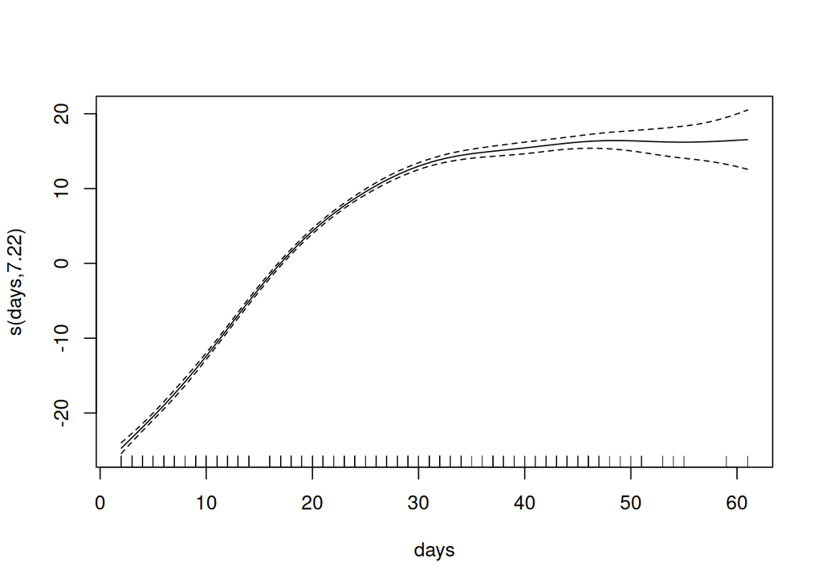

```r
plot(model$gam)
```

## 1.3. Calculate the mean residuals sums for each individuals

```r
#calculate the residuals
residuals_individual <- resid(model$gam)
data$residuals <- residuals_individual
#create a DF with the mean residuals for each individuals
residual_sum <- aggregate(residuals ~ Bague.metal, data = data, sum)
```

## 1.4. Calculate slope of growth for each indivuals before the deceleration point

We identify the end of the rapid growth phase by finding the minimum of the second derivative, which marks the point where growth deceleration is at its strongest, indicating a transition to a slower growth phase:

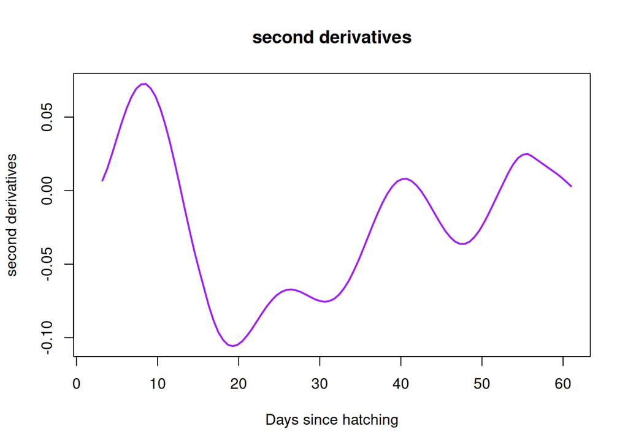

```r
#create the predicted growth curve from the model
prediction_data <- data.frame(days = seq(min(data$days), max(data$days), length.out = 100))
predictions <- predict(model$gam, newdata = prediction_data, type = "response")
prediction_data$tarse_predicted <- predictions

#calculate the slope of the chick growth curve before the onset of deceleration
# extract spline matrix for model predictions.
X <- predict(model$gam, newdata = prediction_data, type = "lpmatrix")
spline_columns <- grep("days", colnames(X))
# compute first and second derivatives of the splines matrix.
dX <- diff(X[, spline_columns]) / diff(prediction_data$days)  #first derivatives of the splines
d2X <- diff(dX) / diff(prediction_data$days[-1])  # second derivatives of the splines
# multiply by the coefficient to obtain the overall derivatives
coefs <- coef(model$gam)
d1 <- dX %*% coefs[spline_columns]  # first derivatives
d2 <- d2X %*% coefs[spline_columns]  # second derivatives

# add the computate derivatives to prediction_data
prediction_data$d1 <- c(NA, d1)  # add NA to align dimensions
prediction_data$d2 <- c(NA, NA, d2)  # two NAs needed for alignment with diff()

#plot the second derivative (to see the deceleration point)
plot(prediction_data$days, prediction_data$d2, type = "l",
     xlab = "Days since hatching", ylab = "second derivatives",
     main = "second derivatives", col = "purple", lwd = 2)
```

```r
#identify the day when the second derivative reaches its minimum (deceleration point)
turning_point <- which.min(prediction_data$d2)
turning_day <- prediction_data$days[turning_point]
#output the deceleration point (19.28 days)
print(turning_day)
```

```
## [1] 19.28283
```

```r
#filter the data for keep only the data before the deceleration point (here 19.28)
datapente <- data[data$days <= 19, ]

#calculate growth slopes for each individual before the deceleration point
#fit a linear model for each individual
get_slope <- function(subset_data) {
  model <- lm(tarse ~ days, data = subset_data)
  return(coef(model)["days"])}
#compute the individual growth rate (with slopes) for each indivuals before the deceleration point (19 days)
pente_individuelle <- datapente %>% group_by(Bague.metal) %>% summarize(slope = get_slope(pick(everything())))
```

# 2. Impact of infection on the modeled growth

## 2.1. Datasets

`data_1` includes data for overall residuals and slope by individual according to their infection status and other variables:

```r
data_1 <- read_excel("Data_Impact of infection on reproductive success_growth_metrics.xlsx")
data_1$Site <- as.factor(data_1$Site)
data_1$Sample <- as.factor(data_1$Sample)
data_1$Year <- as.factor(data_1$Year)
data_1$Age <- as.factor(data_1$Age)
data_1$Sex <- as.factor(data_1$Sex)
data_1$Status_qPCR <- as.factor(data_1$Status_qPCR)
data_1$residuals <- as.numeric(data_1$residuals)
data_1$slope <- as.numeric(data_1$slope)
```

With:  
-Site: sampling colony (Carteau/Frioul)  
-Sample: ID of individual bird  
-Year: sampling year (2022/2023/2024)  
-Age: age of bird (Chick/Adult)  
-Sex: sex of bird (F/M)  
-Status_qPCR: infection status based on qPCR technique (uninfected/infected)  
-residuals: overall indicator of chick growth calculated according to section 1.3.  
-slope: average growth rate of chicks calculated according to section 1.4.  
-Ticks_by_nest: number of ticks collected in the nest  
-Infestation: tick infestation statuts of the nest (infested/uninfested)

Individuals for whom sex have not been determined are removed:

```r
data_1 <- data_1[complete.cases(data_1[ , 5]),]
```

`data_2` includes data for residuals at the time that the blood was drawn, enabling the infectious status and parasitaemia at time t to be determined, and other variables:

```r
data_2 <- read_excel("Data_Impact of infection on reproductive success_growth_metrics_timepoint.xlsx")
data_2$Site <- as.factor(data_2$Site)
data_2$Sample <- as.factor(data_2$Sample)
data_2$Year <- as.factor(data_2$Year)
data_2$Age <- as.factor(data_2$Age)
data_2$Sex <- as.factor(data_2$Sex)
data_2$Days <- as.numeric(data_2$Days)
data_2$Status_qPCR <- as.factor(data_2$Status_qPCR)
data_2$Ratio_qPCR <- as.numeric(data_2$Ratio_qPCR)
data_2$ErrorRatio_qPCR <- as.numeric(data_2$ErrorRatio_qPCR)
data_2$residuals_timet <- as.numeric(data_2$residuals_timet)
```

With:  
-Site: sampling colony (Carteau/Frioul)  
-Sample: ID of individual bird  
-Year: sampling year (2022/2023/2024)  
-Age: age of bird (Chick/Adult)  
-Sex: sex of bird (F/M)  
-Nest:nest of bird  
-Sampling.date: measurement date  
-Hatching.date.estimate: estimated hatching date  
-Days: number of days since hatching  
-Hemoglobin: measure of circulating concentration of hemoglobin  
-Tarsus: length of the tarsus  
-Weight: bird weight  
-RatioWT: ratio between `Weight` and `Tarsus`  
-Status_qPCR: infection status based on qPCR technique (uninfected/infected)  
-Ratio_qPCR: quantification of *Babesia* based on qPCR technique (ratio Larus/*Babesia* copies of genes)  
-ErrorRatio_qPCR: ratio error associated with `Ratio_qPCR`  
-residuals_timet: indicator of chick growth at time t according to section 1.3.  
-Ticks_by_nest: number of ticks collected in the nest  
-Infestation: tick infestation statuts of the nest (infested/uninfested)

Non-infected individuals are removed:

```r
data_2 <- data_2 %>%
  filter(!is.na(Status_qPCR))

data_2 <- data_2[which(data_2$Status_qPCR == "infected"),]
data_2 <- data_2 %>%
  filter(!is.na(Ratio_qPCR))
```

## 2.2. Impact of infection with model residuals

Individuals without `residuals` values and infection status are removed:

```r
data_1 <- data_1[complete.cases(data_1[ , 6]),]
data_1_res <- data_1[complete.cases(data_1[ , 7]),]
```

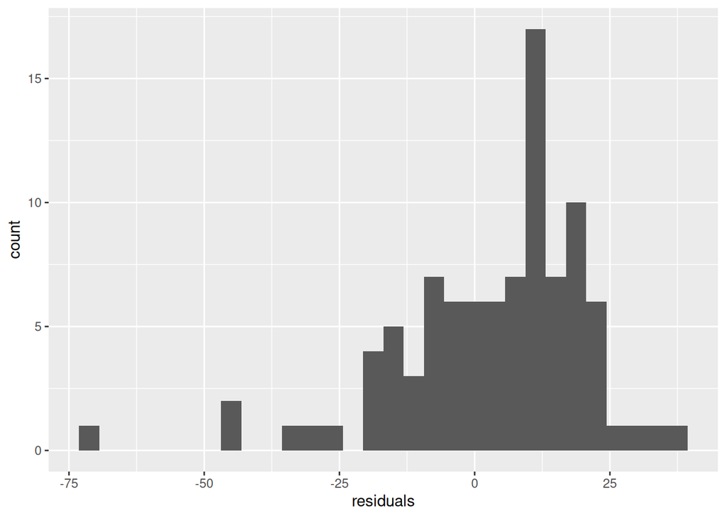

```r
ggplot(data_1_res, aes(x=residuals)) + geom_histogram()
```

```r
shapiro.test(data_1_res$residuals)
```

```
##
##  Shapiro-Wilk normality test
##
## data:  data_1_res$residuals
## W = 0.922, p-value = 3.118e-05
```

Even if p-value is lower than 0.05 (p-value = 3.118e-05), **we will perform the analyses on `data_1_res$residuals` using LMER and check for distribution of model residuals**.

Regarding `residuals_timet`:

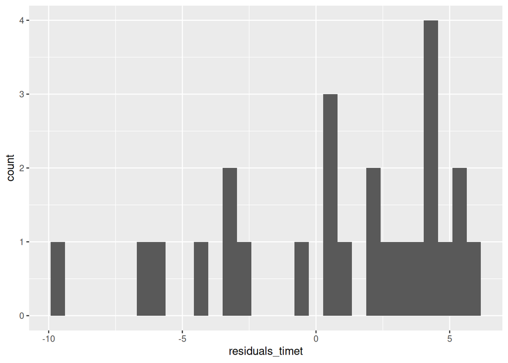

```r
ggplot(data_2, aes(x=residuals_timet)) + geom_histogram()
```

```r
shapiro.test(data_2$residuals_timet)
```

```
##
##  Shapiro-Wilk normality test
##
## data:  data_2$residuals_timet
## W = 0.91497, p-value = 0.0394
```

Even if p-value is lower than 0.05 (p-value = 0.0394), **we will perform the analyses on `data_2$residuals_timet` using LMER and check for distribution of model residuals**.

### 2.2.1. Based on infectious status (binary: infected/uninfected) and `Ticks_by_nest`

We want to test whether `Status_qPCR` is important in models including `Sex` and `Ticks_by_nest` as fixed effects and `Site` and `Year` as random effects in our full LMER model:

```r
lmer_res_1 <- lmer(residuals ~ Status_qPCR + Sex + Ticks_by_nest + (1|Site) + (1|Year), data=data_1_res, na.action = na.fail)
lmer_res_2 <- lmer(residuals ~ Sex + Ticks_by_nest + (1|Site) + (1|Year), data=data_1_res, na.action = na.fail)
anova(lmer_res_1, lmer_res_2, test="Chisq")
```

```
## Data: data_1_res
## Models:
## lmer_res_2: residuals ~ Sex + Ticks_by_nest + (1 | Site) + (1 | Year)
## lmer_res_1: residuals ~ Status_qPCR + Sex + Ticks_by_nest + (1 | Site) + (1 | Year)
##            npar    AIC    BIC  logLik -2*log(L)  Chisq Df Pr(>Chisq)
## lmer_res_2    6 801.35 816.61 -394.68    789.35
## lmer_res_1    7 800.81 818.61 -393.40    786.81 2.5474  1     0.1105
```

```r
AICc(lmer_res_1)
```

```
## [1] 790.3814
```

```r
AICc(lmer_res_2)
```

```
## [1] 795.7478
```

We examine the models:

```r
tab_model(lmer_res_1, lmer_res_2, string.est = "IRR", show.aicc = TRUE, digits=2, show.ci = FALSE, show.intercept = FALSE)
```

|  | residuals |  | residuals |  |
| --- | --- | --- | --- | --- |
| Predictors | IRR | p | IRR | p |
| Status qPCR [uninfected] | 7.49 | 0.067 |  |  |
| Sex [M] | 8.85 | **0.009** | 9.53 | **0.005** |
| Ticks by nest | -0.32 | **0.047** | -0.38 | **0.018** |
| Random Effects |  |  |  |  |
| σ<sup>2</sup> | 246.69 |  | 254.95 |  |
| τ<sub>00</sub> | 14.89 <sub>Year</sub> |  | 15.92 <sub>Year</sub> |  |
|  | 42.26 <sub>Site</sub> |  | 13.07 <sub>Site</sub> |  |
| ICC | 0.19 |  | 0.10 |  |
| N | 2 <sub>Site</sub> |  | 2 <sub>Site</sub> |  |
|  | 3 <sub>Year</sub> |  | 3 <sub>Year</sub> |  |
| Observations | 94 |  | 94 |  |
| Marginal R<sup>2</sup> / Conditional R<sup>2</sup> | 0.168 / 0.324 |  | 0.139 / 0.227 |  |
| AICc | 790.381 |  | 795.748 |  |

Based on these results, we will test whether an interaction is important in the model, still testing the importance of `Status_qPCR`:

```r
lmer_res_3 <- lmer(residuals ~ Status_qPCR + Sex + Ticks_by_nest + Status_qPCR:Sex + (1|Site) + (1|Year), data=data_1_res, na.action = na.fail)
anova(lmer_res_1, lmer_res_3, test="Chisq")
```

```
## Data: data_1_res
## Models:
## lmer_res_1: residuals ~ Status_qPCR + Sex + Ticks_by_nest + (1 | Site) + (1 | Year)
## lmer_res_3: residuals ~ Status_qPCR + Sex + Ticks_by_nest + Status_qPCR:Sex + (1 | Site) + (1 | Year)
##            npar    AIC    BIC logLik -2*log(L) Chisq Df Pr(>Chisq)
## lmer_res_1    7 800.81 818.61 -393.4    786.81
## lmer_res_3    8 802.21 822.56 -393.1    786.21 0.597  1     0.4397
```

```r
lmer_res_4 <- lmer(residuals ~ Status_qPCR + Sex + Ticks_by_nest + Status_qPCR:Ticks_by_nest + (1|Site) + (1|Year), data=data_1_res, na.action = na.fail)
anova(lmer_res_1, lmer_res_4, test="Chisq")
```

```
## Data: data_1_res
## Models:
## lmer_res_1: residuals ~ Status_qPCR + Sex + Ticks_by_nest + (1 | Site) + (1 | Year)
## lmer_res_4: residuals ~ Status_qPCR + Sex + Ticks_by_nest + Status_qPCR:Ticks_by_nest + (1 | Site) + (1 | Year)
##            npar    AIC    BIC  logLik -2*log(L) Chisq Df Pr(>Chisq)
## lmer_res_1    7 800.81 818.61 -393.40    786.81
## lmer_res_4    8 799.73 820.08 -391.87    783.73 3.073  1     0.0796 .
## ---
## Signif. codes:  0 '***' 0.001 '**' 0.01 '*' 0.05 '.' 0.1 ' ' 1
```

```r
lmer_res_5 <- lmer(residuals ~ Sex + Ticks_by_nest + Sex:Ticks_by_nest + (1|Site) + (1|Year), data=data_1_res, na.action = na.fail)
anova(lmer_res_2, lmer_res_5, test="Chisq")
```

```
## Data: data_1_res
## Models:
## lmer_res_2: residuals ~ Sex + Ticks_by_nest + (1 | Site) + (1 | Year)
## lmer_res_5: residuals ~ Sex + Ticks_by_nest + Sex:Ticks_by_nest + (1 | Site) + (1 | Year)
##            npar    AIC    BIC  logLik -2*log(L)  Chisq Df Pr(>Chisq)
## lmer_res_2    6 801.35 816.61 -394.68    789.35
## lmer_res_5    7 800.57 818.38 -393.29    786.57 2.7824  1     0.0953 .
## ---
## Signif. codes:  0 '***' 0.001 '**' 0.01 '*' 0.05 '.' 0.1 ' ' 1
```

```r
tab_model(lmer_res_1, lmer_res_2, lmer_res_3, lmer_res_4, lmer_res_5, string.est = "IRR", show.aicc = TRUE, digits=2, show.ci = FALSE, show.intercept = FALSE)
```

|  | residuals |  | residuals |  | residuals |  | residuals |  | residuals |  |
| --- | --- | --- | --- | --- | --- | --- | --- | --- | --- | --- |
| Predictors | IRR | p | IRR | p | IRR | p | IRR | p | IRR | p |
| Status qPCR [uninfected] | 7.49 | 0.067 |  |  | 4.53 | 0.423 | 10.88 | **0.016** |  |  |
| Sex [M] | 8.85 | **0.009** | 9.53 | **0.005** | 5.43 | 0.331 | 9.88 | **0.004** | 12.93 | **0.001** |
| Ticks by nest | -0.32 | **0.047** | -0.38 | **0.018** | -0.34 | **0.036** | -0.15 | 0.403 | -0.23 | 0.201 |
| Status qPCR [uninfected] × Sex [M] |  |  |  |  | 5.34 | 0.447 |  |  |  |  |
| Status qPCR [uninfected] × Ticks by nest |  |  |  |  |  |  | -0.66 | 0.079 |  |  |
| Sex [M] × Ticks by nest |  |  |  |  |  |  |  |  | -0.56 | 0.099 |
| Random Effects |  |  |  |  |  |  |  |  |  |  |
| σ<sup>2</sup> | 246.69 |  | 254.95 |  | 247.97 |  | 239.58 |  | 249.58 |  |
| τ<sub>00</sub> | 14.89 <sub>Year</sub> |  | 15.92 <sub>Year</sub> |  | 14.16 <sub>Year</sub> |  | 22.65 <sub>Year</sub> |  | 19.55 <sub>Year</sub> |  |
|  | 42.26 <sub>Site</sub> |  | 13.07 <sub>Site</sub> |  | 43.46 <sub>Site</sub> |  | 39.86 <sub>Site</sub> |  | 10.89 <sub>Site</sub> |  |
| ICC | 0.19 |  | 0.10 |  | 0.19 |  | 0.21 |  | 0.11 |  |
| N | 2 <sub>Site</sub> |  | 2 <sub>Site</sub> |  | 2 <sub>Site</sub> |  | 2 <sub>Site</sub> |  | 2 <sub>Site</sub> |  |
|  | 3 <sub>Year</sub> |  | 3 <sub>Year</sub> |  | 3 <sub>Year</sub> |  | 3 <sub>Year</sub> |  | 3 <sub>Year</sub> |  |
| Observations | 94 |  | 94 |  | 94 |  | 94 |  | 94 |  |
| Marginal R<sup>2</sup> / Conditional R<sup>2</sup> | 0.168 / 0.324 |  | 0.139 / 0.227 |  | 0.171 / 0.328 |  | 0.181 / 0.350 |  | 0.157 / 0.249 |  |
| AICc | 790.381 |  | 795.748 |  | 786.464 |  | 789.872 |  | 795.699 |  |

Based on these results, the significative impact of `Status_qPCR` can be slight in the model, as the model with the lowest AICc is `Status_qPCR + Sex + Ticks_by_nest + Status_qPCR:Sex + (1|Site) + (1|Year)` but the ANOVA didn’t indicate a significative difference between models.

The interpretation of this model highlights that growth is a factor that is difficult to explain using a single variable. Indeed, even though most predictors except `Ticks_by_nest` (IRR = -0.34, p = 0.036) are not significant individually (Status_qPCR, IRR = 4.53, p = 0.423; Sex, IRR = 5.43, p = 0.331; Status_qPCR:Sex, IRR = 5.34, p = 0.447), the combination of predictors (Status_qPCR, Sex, Ticks_by_nest, and their interaction) plus the random effects structure yields the most parsimonious fit to your data. Among the candidate models, this one provides the best balance between model complexity and explanatory power. The fact that `Ticks_by_nest` is the only significant fixed effect suggests that this variable is driving most of the explanatory power, while the other variables may still contribute slightly to fit.

We examine the best-fitted model:

```r
summary(lmer_res_3)
```

```
## Linear mixed model fit by REML ['lmerMod']
## Formula: residuals ~ Status_qPCR + Sex + Ticks_by_nest + Status_qPCR:Sex +
##     (1 | Site) + (1 | Year)
##    Data: data_1_res
##
## REML criterion at convergence: 768.8
##
## Scaled residuals:
##     Min      1Q  Median      3Q     Max
## -3.8430 -0.4435  0.1485  0.5994  1.9773
##
## Random effects:
##  Groups   Name        Variance Std.Dev.
##  Year     (Intercept)  14.16    3.763
##  Site     (Intercept)  43.46    6.593
##  Residual             247.97   15.747
## Number of obs: 94, groups:  Year, 3; Site, 2
##
## Fixed effects:
##                            Estimate Std. Error t value
## (Intercept)                 -2.3848     6.8863  -0.346
## Status_qPCRuninfected        4.5285     5.6190   0.806
## SexM                         5.4324     5.5622   0.977
## Ticks_by_nest               -0.3444     0.1619  -2.127
## Status_qPCRuninfected:SexM   5.3413     6.9920   0.764
##
## Correlation of Fixed Effects:
##             (Intr) St_PCR SexM   Tcks__
## Stts_qPCRnn -0.526
## SexM        -0.441  0.514
## Tcks_by_nst -0.339  0.300  0.199
## Stts_PCR:SM  0.365 -0.694 -0.803 -0.184
```

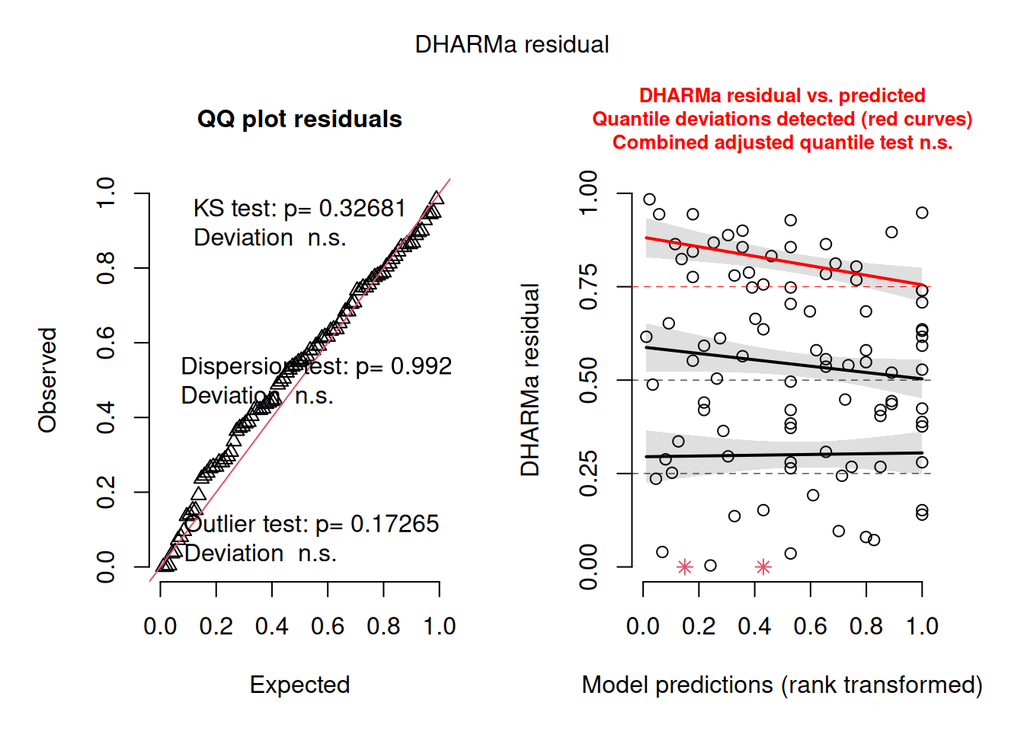

```r
simulationOutput_res <- simulateResiduals(fittedModel = lmer_res_3, plot = F)
plot(simulationOutput_res)
```

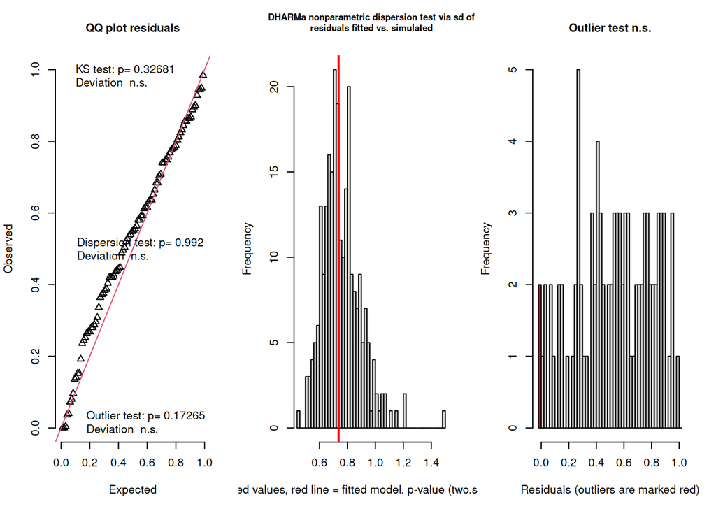

```
## $uniformity
##
##  Asymptotic one-sample Kolmogorov-Smirnov test
##
## data:  simulationOutput$scaledResiduals
## D = 0.098043, p-value = 0.3268
## alternative hypothesis: two-sided
##
##
## $dispersion
##
##  DHARMa nonparametric dispersion test via sd of residuals fitted vs.
##  simulated
##
## data:  simulationOutput
## dispersion = 0.9704, p-value = 0.992
## alternative hypothesis: two.sided
##
##
## $outliers
##
##  DHARMa outlier test based on exact binomial test with approximate
##  expectations
##
## data:  simulationOutput
## outliers at both margin(s) = 2, observations = 94, p-value = 0.1726
## alternative hypothesis: true probability of success is not equal to 0.007968127
## 95 percent confidence interval:
##  0.002587161 0.074751766
## sample estimates:
## frequency of outliers (expected: 0.00796812749003984 )
##                                              0.0212766
```

```r
testResiduals(simulationOutput_res)
```

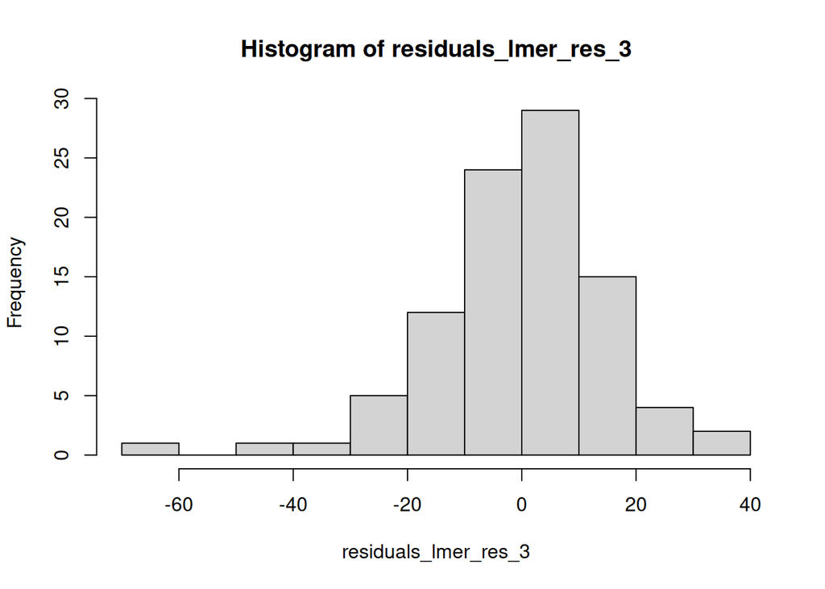

```r
residuals_lmer_res_3 <- residuals(lmer_res_3)
hist(residuals_lmer_res_3)
```

```r
shapiro.test(residuals(lmer_res_3))
```

```
##
##  Shapiro-Wilk normality test
##
## data:  residuals(lmer_res_3)
## W = 0.95406, p-value = 0.002301
```

Based on these tests:  
-Uniformity test: since p > 0.05, the residuals do not significantly deviate from uniformity, meaning the residuals are acceptable  
-Dispersion test: Since p > 0.05, there’s no evidence of overdispersion or underdispersion  
-Outlier test: since p > 0.05, the number of outliers is not excessive and is within the expected range.  
**We consider `Status_qPCR + Sex + Ticks_by_nest + Sex:Status_qPCR + (1|Site) + (1|Year)` as the best-fitted model.**

**Nevertheless, the infection status appears to influence slightly the growth of birds based on calculated residuals.**

Visualisation:

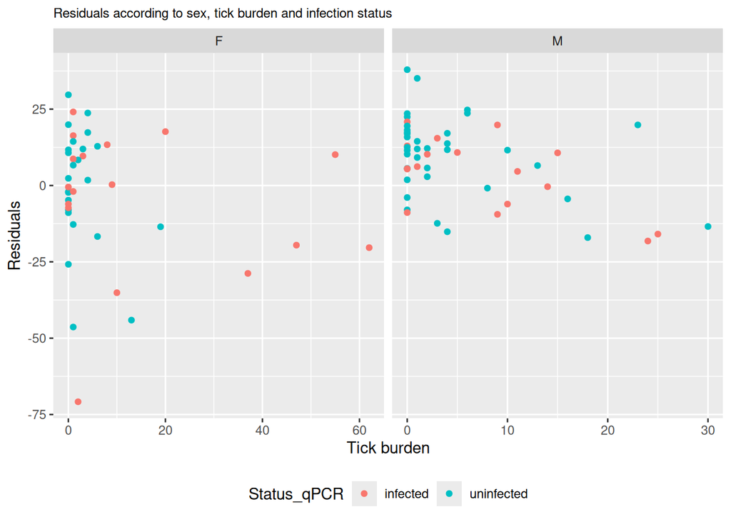

```r
plotA <- ggplot(data_1_res, aes(x= Ticks_by_nest, y= residuals, color=Status_qPCR, fill = Status_qPCR))+
  geom_point() +
labs(x = "Tick burden",
       y = "Residuals",
       title = "Residuals according to sex, tick burden and infection status")+
  theme(plot.title = element_text(size = 9),
        legend.position = "bottom") +
  facet_grid(~Sex,scales = "free")
plotA
```

### 2.2.2. Based on parasitemia (continuous) and `Ticks_by_nest`

In this section, we based our analyses on `residuals_timet` that correspond to residuals at the time that the blood was drawn, enabling to match with the parasitemia at this exact time t.

```r
data_2$log_ratio_qPCR <- log10(data_2$Ratio_qPCR)
```

We want to test whether `log_ratio_qPCR` is important in models including `Sex` and `Ticks_by_nest` as fixed effects and `Site` and `Year` as random effects in our full LMER model:

```r
lmer_res_ratio_1 <- lmer(residuals_timet ~ log_ratio_qPCR + Sex + Ticks_by_nest + (1|Site) + (1| Year), data=data_2, na.action = na.fail)
lmer_res_ratio_2 <- lmer(residuals_timet ~ Sex + Ticks_by_nest + (1|Site) + (1| Year), data=data_2, na.action = na.fail)
anova(lmer_res_ratio_1, lmer_res_ratio_2, test="Chisq")
```

```
## Data: data_2
## Models:
## lmer_res_ratio_2: residuals_timet ~ Sex + Ticks_by_nest + (1 | Site) + (1 | Year)
## lmer_res_ratio_1: residuals_timet ~ log_ratio_qPCR + Sex + Ticks_by_nest + (1 | Site) + (1 | Year)
##                  npar    AIC    BIC  logLik -2*log(L)  Chisq Df Pr(>Chisq)
## lmer_res_ratio_2    6 151.58 158.89 -69.790    139.58
## lmer_res_ratio_1    7 142.68 151.21 -64.338    128.68 10.903  1  0.0009601 ***
## ---
## Signif. codes:  0 '***' 0.001 '**' 0.01 '*' 0.05 '.' 0.1 ' ' 1
```

```r
AICc(lmer_res_ratio_1)
```

```
## [1] 150.1695
```

```r
AICc(lmer_res_ratio_2)
```

```
## [1] 154.5559
```

**Including the `log_ratio_qPCR` variable in the model significantly improves the explanation of the residuals variable based on the ANOVA result.**

We examine the models:

```r
tab_model(lmer_res_ratio_1, lmer_res_ratio_2, string.est = "IRR", show.aicc = TRUE, digits=2, show.ci = FALSE, show.intercept = FALSE)
```

|  | residuals_timet |  | residuals_timet |  |
| --- | --- | --- | --- | --- |
| Predictors | IRR | p | IRR | p |
| log ratio qPCR | -1.31 | **0.004** |  |  |
| Sex [M] | 2.78 | 0.067 | 2.06 | 0.215 |
| Ticks by nest | 0.08 | 0.184 | 0.07 | 0.325 |
| Random Effects |  |  |  |  |
| σ<sup>2</sup> | 11.56 |  | 14.65 |  |
| τ<sub>00</sub> | 0.83 <sub>Year</sub> |  | 7.88 <sub>Year</sub> |  |
|  | 0.00 <sub>Site</sub> |  | 0.00 <sub>Site</sub> |  |
| N | 2 <sub>Site</sub> |  | 2 <sub>Site</sub> |  |
|  | 3 <sub>Year</sub> |  | 3 <sub>Year</sub> |  |
| Observations | 25 |  | 25 |  |
| Marginal R<sup>2</sup> / Conditional R<sup>2</sup> | 0.380 / NA |  | 0.096 / NA |  |
| AICc | 150.169 |  | 154.556 |  |

Based on these results, we will test whether `Sex` and `Ticks_by_nest` are important in the model, still testing the importance of `log_ratio_qPCR`:

```r
lmer_res_ratio_3 <- lmer(residuals_timet ~ log_ratio_qPCR + Sex + (1|Site) + (1| Year), data=data_2, na.action = na.fail)
lmer_res_ratio_4 <- lmer(residuals_timet ~ log_ratio_qPCR + Ticks_by_nest + (1|Site) + (1| Year), data=data_2, na.action = na.fail)
lmer_res_ratio_5 <- lmer(residuals_timet ~ log_ratio_qPCR + (1|Site) + (1| Year), data=data_2, na.action = na.fail)
lmer_res_ratio_6 <- lmer(residuals_timet ~ Sex + (1|Site) + (1| Year), data=data_2, na.action = na.fail)
lmer_res_ratio_null <- lmer(residuals_timet ~ 1 + (1|Site) + (1|Year), data=data_2, na.action = na.fail)

anova_res_ratio_1 <- anova(lmer_res_ratio_1, lmer_res_ratio_3, test="Chisq")
anova_res_ratio_2 <- anova(lmer_res_ratio_1, lmer_res_ratio_4, test="Chisq")
anova_res_ratio_3 <- anova(lmer_res_ratio_3, lmer_res_ratio_5, test="Chisq")
anova_res_ratio_4 <- anova(lmer_res_ratio_5, lmer_res_ratio_null, test="Chisq")
anova_res_ratio_5 <- anova(lmer_res_ratio_6, lmer_res_ratio_null, test="Chisq")

p_value_anova_res_ratio_1 <- anova_res_ratio_1$`Pr(>Chisq)`[2]
p_value_anova_res_ratio_2 <- anova_res_ratio_2$`Pr(>Chisq)`[2]
p_value_anova_res_ratio_3 <- anova_res_ratio_3$`Pr(>Chisq)`[2]
p_value_anova_res_ratio_4 <- anova_res_ratio_4$`Pr(>Chisq)`[2]
p_value_anova_res_ratio_5 <- anova_res_ratio_5$`Pr(>Chisq)`[2]

anova_results_res_ratio <- data.frame(
  Comparison = c("log_ratio_qPCR+Sex+Ticks_by_nest vs log_ratio_qPCR+Sex", "log_ratio_qPCR+Sex+Ticks_by_nest vs log_ratio_qPCR+Ticks_by_nest", "log_ratio_qPCR+Sex vs log_ratio_qPCR", "log_ratio_qPCR vs null", "Sex vs null"),
  P_value = c(p_value_anova_res_ratio_1, p_value_anova_res_ratio_2, p_value_anova_res_ratio_3, p_value_anova_res_ratio_4, p_value_anova_res_ratio_5))

anova_results_res_ratio %>%
  kable(caption = "ANOVA Results between models") %>%
  kable_styling(bootstrap_options = c("striped", "hover", "condensed", "responsive"))
```

ANOVA Results between models

| Comparison | P_value |
| --- | --- |
| log_ratio_qPCR+Sex+Ticks_by_nest vs log_ratio_qPCR+Sex | 0.1663097 |
| log_ratio_qPCR+Sex+Ticks_by_nest vs log_ratio_qPCR+Ticks_by_nest | 0.0398965 |
| log_ratio_qPCR+Sex vs log_ratio_qPCR | 0.0887403 |
| log_ratio_qPCR vs null | 0.0043981 |
| Sex vs null | 0.1691084 |

```r
tab_model(lmer_res_ratio_1, lmer_res_ratio_2, lmer_res_ratio_3, lmer_res_ratio_4, lmer_res_ratio_5, lmer_res_ratio_6, lmer_res_ratio_null, string.est = "IRR", show.aicc = TRUE, digits=2, show.ci = FALSE, show.intercept = FALSE)
```

|  | residuals_timet |  | residuals_timet |  | residuals_timet |  | residuals_timet |  | residuals_timet |  | residuals_timet |  | residuals_timet |  |
| --- | --- | --- | --- | --- | --- | --- | --- | --- | --- | --- | --- | --- | --- | --- |
| Predictors | IRR | p | IRR | p | IRR | p | IRR | p | IRR | p | IRR | p | IRR | p |
| log ratio qPCR | -1.31 | **0.004** |  |  | -1.14 | **0.005** | -1.28 | **0.006** | -1.21 | **0.003** |  |  |  |  |
| Sex [M] | 2.78 | 0.067 | 2.06 | 0.215 | 2.21 | 0.135 |  |  |  |  | 2.04 | 0.220 |  |  |
| Ticks by nest | 0.08 | 0.184 | 0.07 | 0.325 |  |  | 0.04 | 0.448 |  |  |  |  |  |  |
| Random Effects |  |  |  |  |  |  |  |  |  |  |  |  |  |  |
| σ<sup>2</sup> | 11.56 |  | 14.65 |  | 12.22 |  | 12.52 |  | 12.45 |  | 15.40 |  | 15.35 |  |
| τ<sub>00</sub> | 0.83 <sub>Year</sub> |  | 7.88 <sub>Year</sub> |  | 0.00 <sub>Year</sub> |  | 0.79 <sub>Year</sub> |  | 0.00 <sub>Year</sub> |  | 2.75 <sub>Year</sub> |  | 4.40 <sub>Year</sub> |  |
|  | 0.00 <sub>Site</sub> |  | 0.00 <sub>Site</sub> |  | 0.40 <sub>Site</sub> |  | 1.63 <sub>Site</sub> |  | 2.38 <sub>Site</sub> |  | 0.00 <sub>Site</sub> |  | 0.00 <sub>Site</sub> |  |
| ICC |  |  |  |  | 0.03 |  | 0.16 |  |  |  |  |  |  |  |
| N | 2 <sub>Site</sub> |  | 2 <sub>Site</sub> |  | 2 <sub>Site</sub> |  | 2 <sub>Site</sub> |  | 2 <sub>Site</sub> |  | 2 <sub>Site</sub> |  | 2 <sub>Site</sub> |  |
|  | 3 <sub>Year</sub> |  | 3 <sub>Year</sub> |  | 3 <sub>Year</sub> |  | 3 <sub>Year</sub> |  | 3 <sub>Year</sub> |  | 3 <sub>Year</sub> |  | 3 <sub>Year</sub> |  |
| Observations | 25 |  | 25 |  | 25 |  | 25 |  | 25 |  | 25 |  | 25 |  |
| Marginal R<sup>2</sup> / Conditional R<sup>2</sup> | 0.380 / NA |  | 0.096 / NA |  | 0.348 / 0.369 |  | 0.270 / 0.388 |  | 0.320 / NA |  | 0.066 / NA |  | 0.000 / NA |  |
| AICc | 150.169 |  | 154.556 |  | 143.994 |  | 152.166 |  | 145.138 |  | 148.110 |  | 149.261 |  |

Based on these results:  
- The AICc of the model with `log_ratio_qPCR` and `Sex` is the lowest, even if the effect of `Sex` is not as significant as the one of `log_ratio_qPCR`.  
- The ANOVA between `log_ratio_qPCR + Sex` and `log_ratio_qPCR` suggest that the addition of `Sex` is not significant. Based on these results, the best-fitted model appears to be `log_ratio_qPCR + (1|Site) + (1|Year)`.

We examine the best-fitted model:

```r
summary(lmer_res_ratio_5)
```

```
## Linear mixed model fit by REML ['lmerMod']
## Formula: residuals_timet ~ log_ratio_qPCR + (1 | Site) + (1 | Year)
##    Data: data_2
##
## REML criterion at convergence: 132
##
## Scaled residuals:
##     Min      1Q  Median      3Q     Max
## -2.1858 -0.4279  0.1426  0.5584  1.5978
##
## Random effects:
##  Groups   Name        Variance Std.Dev.
##  Year     (Intercept)  0.00    0.000
##  Site     (Intercept)  2.38    1.543
##  Residual             12.45    3.529
## Number of obs: 25, groups:  Year, 3; Site, 2
##
## Fixed effects:
##                Estimate Std. Error t value
## (Intercept)     -6.0041     2.3651  -2.539
## log_ratio_qPCR  -1.2071     0.3619  -3.335
##
## Correlation of Fixed Effects:
##             (Intr)
## log_rt_qPCR 0.817
## optimizer (nloptwrap) convergence code: 0 (OK)
## boundary (singular) fit: see help('isSingular')
```

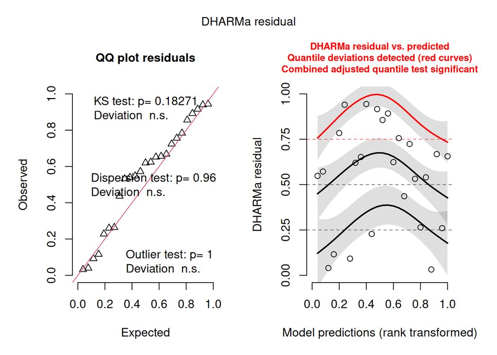

```r
simulationOutput_res_ratio <- simulateResiduals(fittedModel = lmer_res_ratio_5, plot = F)
plot(simulationOutput_res_ratio)
```

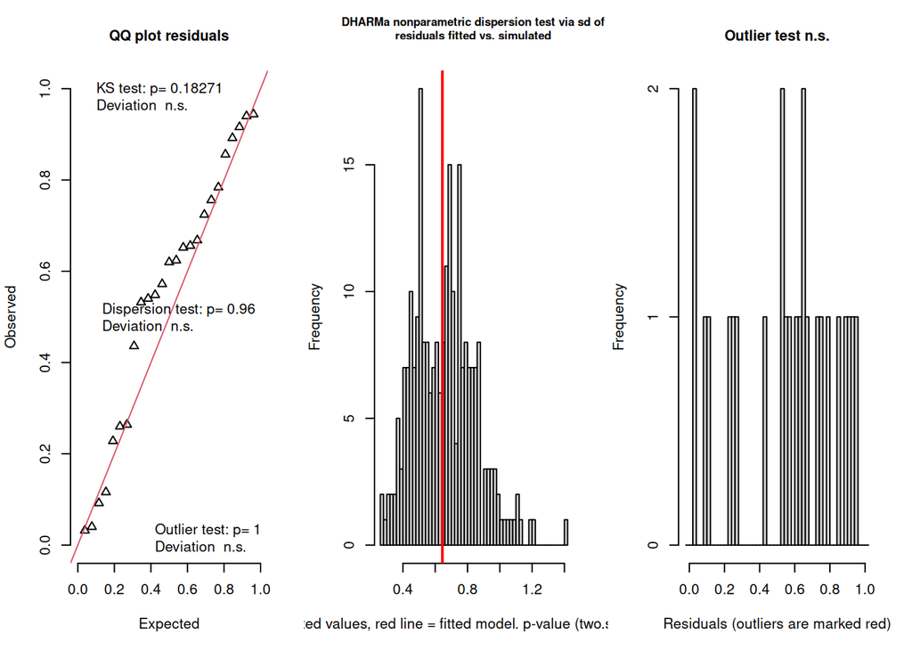

```
## $uniformity
##
##  Exact one-sample Kolmogorov-Smirnov test
##
## data:  simulationOutput$scaledResiduals
## D = 0.212, p-value = 0.1827
## alternative hypothesis: two-sided
##
##
## $dispersion
##
##  DHARMa nonparametric dispersion test via sd of residuals fitted vs.
##  simulated
##
## data:  simulationOutput
## dispersion = 0.98201, p-value = 0.96
## alternative hypothesis: two.sided
##
##
## $outliers
##
##  DHARMa outlier test based on exact binomial test with approximate
##  expectations
##
## data:  simulationOutput
## outliers at both margin(s) = 0, observations = 25, p-value = 1
## alternative hypothesis: true probability of success is not equal to 0.007968127
## 95 percent confidence interval:
##  0.0000000 0.1371852
## sample estimates:
## frequency of outliers (expected: 0.00796812749003984 )
##                                                      0
```

```r
testResiduals(simulationOutput_res_ratio)
```

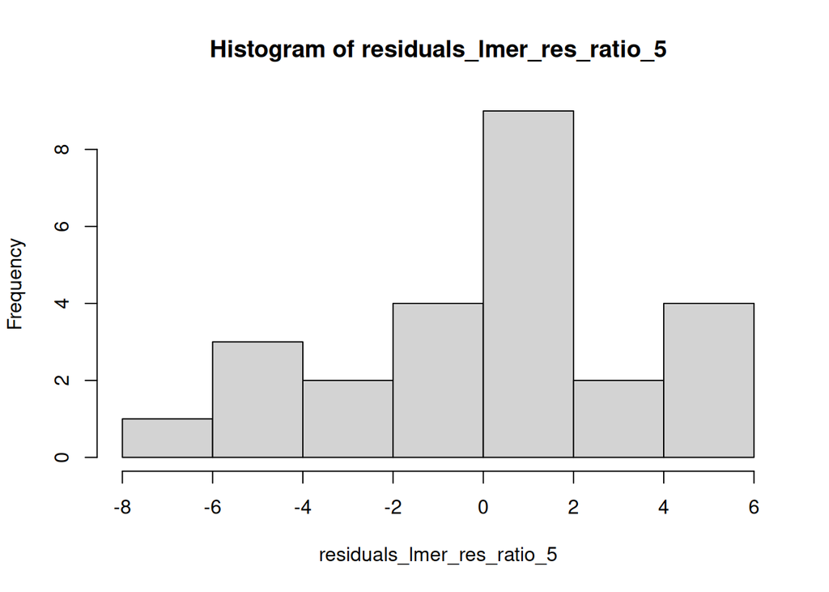

```r
residuals_lmer_res_ratio_5 <- residuals(lmer_res_ratio_5)
hist(residuals_lmer_res_ratio_5)
```

```r
shapiro.test(residuals(lmer_res_ratio_5))
```

```
##
##  Shapiro-Wilk normality test
##
## data:  residuals(lmer_res_ratio_5)
## W = 0.9659, p-value = 0.5439
```

Based on these tests, **we consider `log_ratio_qPCR + (1|Site) + (1|Year)` as the best-fitted model.**

**The residuals at the time that parasitemia was measured are influenced by the *Babesia* load. There is a negative correlation between the residuals and the parasitemia (IRR = -1.21, p = 0.003).**

Visualisation:

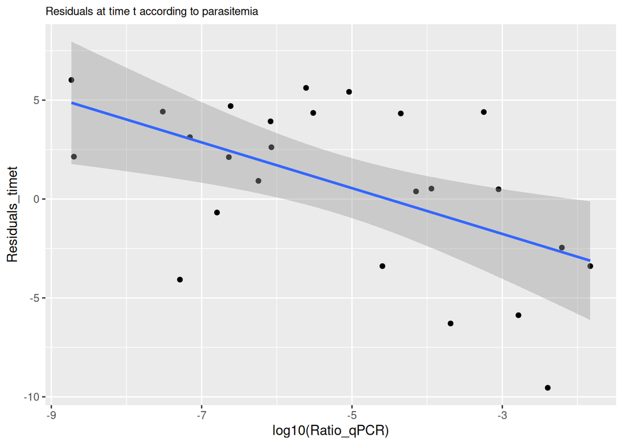

```r
plotB <- ggplot(data_2, aes(x= log_ratio_qPCR, y= residuals_timet)) +
  geom_point() +
  geom_smooth(method = lm) +
  labs(x = "log10(Ratio_qPCR)",
       y = "Residuals_timet",
       title = "Residuals at time t according to parasitemia")+
  theme(plot.title = element_text(size = 9))
plotB
```

## 2.3. Impact of infection with model slope

Individuals without `slope` values are removed:

```r
data_1_slope <- data_1[complete.cases(data_1[ , 8]),]
```

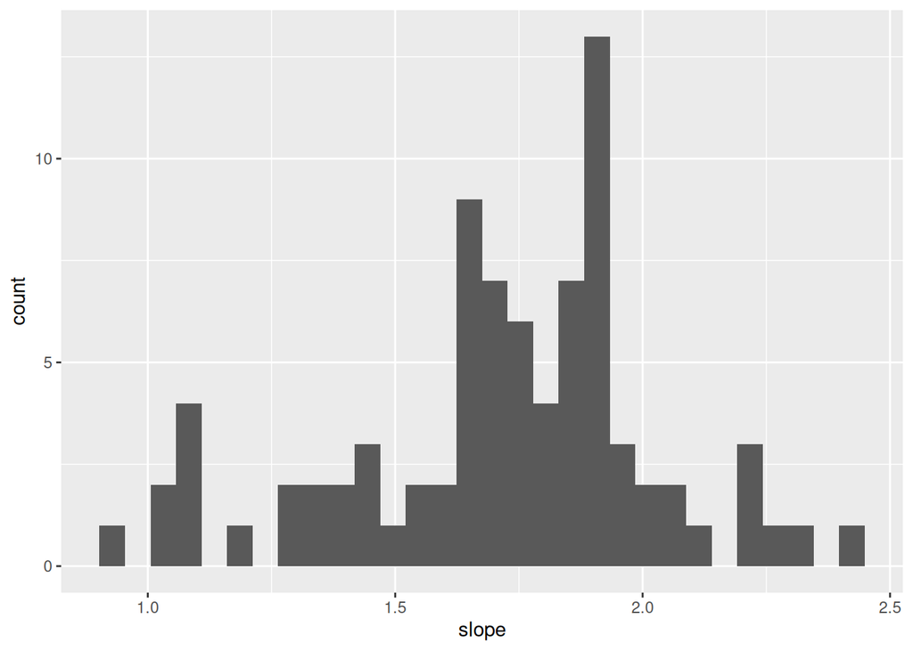

```r
ggplot(data_1_slope, aes(x=slope)) + geom_histogram()
```

```r
shapiro.test(data_1_slope$slope)
```

```
##
##  Shapiro-Wilk normality test
##
## data:  data_1_slope$slope
## W = 0.95519, p-value = 0.006038
```

Even if p-value is lower than 0.05 (p-value = 0.006038), **we will perform the analyses on `data_1_slope$slope` using LMER and check for distribution of model residuals**.

### 2.3.1. Based on infectious status (binary: infected/uninfected) and `Ticks_by_nest`

We want to test whether `Status_qPCR` is important in models including `Sex` and `Ticks_by_nest` as fixed effects and `Site` and `Year` as random effects in our full LMER model:

```r
lmer_slope_1 <- lmer(slope ~ Status_qPCR + Sex + Ticks_by_nest + (1|Site) + (1|Year), data=data_1_slope, na.action = na.fail)
lmer_slope_2 <- lmer(slope ~ Sex + Ticks_by_nest + (1|Site) + (1|Year), data=data_1_slope, na.action = na.fail)
anova(lmer_slope_1, lmer_slope_2, test="Chisq")
```

```
## Data: data_1_slope
## Models:
## lmer_slope_2: slope ~ Sex + Ticks_by_nest + (1 | Site) + (1 | Year)
## lmer_slope_1: slope ~ Status_qPCR + Sex + Ticks_by_nest + (1 | Site) + (1 | Year)
##              npar    AIC    BIC  logLik -2*log(L)  Chisq Df Pr(>Chisq)
## lmer_slope_2    6 41.344 55.785 -14.672    29.344
## lmer_slope_1    7 40.420 57.267 -13.210    26.420 2.9241  1    0.08726 .
## ---
## Signif. codes:  0 '***' 0.001 '**' 0.01 '*' 0.05 '.' 0.1 ' ' 1
```

```r
AICc(lmer_slope_1)
```

```
## [1] 61.95645
```

```r
AICc(lmer_slope_2)
```

```
## [1] 59.79602
```

**Including the `Status_qPCR` variable in the model significantly doesn’t improve the explanation of the slope variable based on the ANOVA result, while including `Sex` and `Ticks_by_nest`.**

We examine the models:

```r
tab_model(lmer_slope_1, lmer_slope_2, string.est = "IRR", show.aicc = TRUE, digits=2, show.ci = FALSE, show.intercept = FALSE)
```

|  | slope |  | slope |  |
| --- | --- | --- | --- | --- |
| Predictors | IRR | p | IRR | p |
| Status qPCR [uninfected] | 0.15 | 0.053 |  |  |
| Sex [M] | 0.08 | 0.237 | 0.09 | 0.151 |
| Ticks by nest | -0.01 | **0.011** | -0.01 | **0.003** |
| Random Effects |  |  |  |  |
| σ<sup>2</sup> | 0.08 |  | 0.08 |  |
| τ<sub>00</sub> | 0.00 <sub>Year</sub> |  | 0.00 <sub>Year</sub> |  |
|  | 0.02 <sub>Site</sub> |  | 0.01 <sub>Site</sub> |  |
| ICC | 0.21 |  | 0.10 |  |
| N | 2 <sub>Site</sub> |  | 2 <sub>Site</sub> |  |
|  | 3 <sub>Year</sub> |  | 3 <sub>Year</sub> |  |
| Observations | 82 |  | 82 |  |
| Marginal R<sup>2</sup> / Conditional R<sup>2</sup> | 0.172 / 0.348 |  | 0.135 / 0.225 |  |
| AICc | 61.956 |  | 59.796 |  |

Based on these results, we will test whether `Sex` is important in the model, still testing the importance of `Status_qPCR`:

```r
lmer_slope_3 <- lmer(slope ~ Status_qPCR + Ticks_by_nest + (1|Site) + (1|Year), data=data_1_slope, na.action = na.fail)
lmer_slope_4 <- lmer(slope ~ Status_qPCR * Ticks_by_nest + (1|Site) + (1|Year), data=data_1_slope, na.action = na.fail)
lmer_slope_5 <- lmer(slope ~ Status_qPCR + (1|Site) + (1|Year), data=data_1_slope, na.action = na.fail)
lmer_slope_6 <- lmer(slope ~ Ticks_by_nest + (1|Site) + (1|Year), data=data_1_slope, na.action = na.fail)
lmer_slope_null <- lmer(slope ~ 1 + (1|Site) + (1|Year), data=data_1_slope, na.action = na.fail)

anova_slope_1 <- anova(lmer_slope_1, lmer_slope_3, test="Chisq")
anova_slope_2 <- anova(lmer_slope_3, lmer_slope_4, test="Chisq")
anova_slope_3 <- anova(lmer_slope_3, lmer_slope_5, test="Chisq")
anova_slope_4 <- anova(lmer_slope_3, lmer_slope_6, test="Chisq")
anova_slope_5 <- anova(lmer_slope_5, lmer_slope_null, test="Chisq")

p_value_anova_slope_1 <- anova_slope_1$`Pr(>Chisq)`[2]
p_value_anova_slope_2 <- anova_slope_2$`Pr(>Chisq)`[2]
p_value_anova_slope_3 <- anova_slope_3$`Pr(>Chisq)`[2]
p_value_anova_slope_4 <- anova_slope_4$`Pr(>Chisq)`[2]
p_value_anova_slope_5 <- anova_slope_5$`Pr(>Chisq)`[2]

anova_results_slope <- data.frame(
  Comparison = c("Status_qPCR+Ticks_by_nest+Sex vs Status_qPCR+Ticks_by_nest", "Status_qPCR+Ticks_by_nest vs Status_qPCR*Ticks_by_nest", "Status_qPCR+Ticks_by_nest vs Status_qPCR", "Status_qPCR+Ticks_by_nest vs Ticks_by_nest", "Status_qPCR vs null"),
  P_value = c(p_value_anova_slope_1, p_value_anova_slope_2, p_value_anova_slope_3, p_value_anova_slope_4, p_value_anova_slope_5))

anova_results_slope %>%
  kable(caption = "ANOVA Results between models") %>%
  kable_styling(bootstrap_options = c("striped", "hover", "condensed", "responsive"))
```

ANOVA Results between models

| Comparison | P_value |
| --- | --- |
| Status_qPCR+Ticks_by_nest+Sex vs Status_qPCR+Ticks_by_nest | 0.2130305 |
| Status_qPCR+Ticks_by_nest vs Status_qPCR*Ticks_by_nest | 0.2445144 |
| Status_qPCR+Ticks_by_nest vs Status_qPCR | 0.0091754 |
| Status_qPCR+Ticks_by_nest vs Ticks_by_nest | 0.0594179 |
| Status_qPCR vs null | 0.0171714 |

```r
tab_model(lmer_slope_1, lmer_slope_3, lmer_slope_4, lmer_slope_5, lmer_slope_6, lmer_slope_null, string.est = "IRR", show.aicc = TRUE, digits=2, show.ci = FALSE, show.intercept = FALSE)
```

|  | slope |  | slope |  | slope |  | slope |  | slope |  | slope |  |
| --- | --- | --- | --- | --- | --- | --- | --- | --- | --- | --- | --- | --- |
| Predictors | IRR | p | IRR | p | IRR | p | IRR | p | IRR | p | IRR | p |
| Status qPCR [uninfected] | 0.15 | 0.053 | 0.17 | **0.035** | 0.21 | **0.016** | 0.21 | **0.007** |  |  |  |  |
| Sex [M] | 0.08 | 0.237 |  |  |  |  |  |  |  |  |  |  |
| Ticks by nest | -0.01 | **0.011** | -0.01 | **0.008** | -0.01 | 0.071 |  |  | -0.01 | **0.002** |  |  |
| Status qPCR [uninfected] × Ticks by nest |  |  |  |  | -0.01 | 0.241 |  |  |  |  |  |  |
| Random Effects |  |  |  |  |  |  |  |  |  |  |  |  |
| σ<sup>2</sup> | 0.08 |  | 0.08 |  | 0.08 |  | 0.08 |  | 0.08 |  | 0.09 |  |
| τ<sub>00</sub> | 0.00 <sub>Year</sub> |  | 0.00 <sub>Year</sub> |  | 0.00 <sub>Year</sub> |  | 0.01 <sub>Year</sub> |  | 0.00 <sub>Year</sub> |  | 0.01 <sub>Year</sub> |  |
|  | 0.02 <sub>Site</sub> |  | 0.02 <sub>Site</sub> |  | 0.02 <sub>Site</sub> |  | 0.02 <sub>Site</sub> |  | 0.01 <sub>Site</sub> |  | 0.00 <sub>Site</sub> |  |
| ICC | 0.21 |  | 0.23 |  | 0.24 |  | 0.23 |  | 0.11 |  | 0.13 |  |
| N | 2 <sub>Site</sub> |  | 2 <sub>Site</sub> |  | 2 <sub>Site</sub> |  | 2 <sub>Site</sub> |  | 2 <sub>Site</sub> |  | 2 <sub>Site</sub> |  |
|  | 3 <sub>Year</sub> |  | 3 <sub>Year</sub> |  | 3 <sub>Year</sub> |  | 3 <sub>Year</sub> |  | 3 <sub>Year</sub> |  | 3 <sub>Year</sub> |  |
| Observations | 82 |  | 82 |  | 82 |  | 82 |  | 82 |  | 82 |  |
| Marginal R<sup>2</sup> / Conditional R<sup>2</sup> | 0.172 / 0.348 |  | 0.166 / 0.357 |  | 0.170 / 0.367 |  | 0.086 / 0.293 |  | 0.119 / 0.215 |  | 0.000 / 0.128 |  |
| AICc | 61.956 |  | 57.292 |  | 66.464 |  | 51.752 |  | 55.895 |  | 52.521 |  |

Based on these results, the best-fitted model appears to be `Status_qPCR + Ticks_by_nest + (1|Site) + (1|Year)` or `Status_qPCR + (1|Site) + (1|Year)`: - The AICc of `Status_qPCR + (1|Site) + (1|Year)` model is the lowest (AICc = 51.75), giving a significant impact of `Status_qPCR` on the growth with uninfected individuals having a higher sloper (IRR = 0.21, p = 0.007)  
- But the ANOVA between `Status_qPCR + Ticks_by_nest + (1|Site) + (1|Year)` and `Status_qPCR + (1|Site) + (1|Year)` (p-value = 0.009) is indicative of an impact of `Ticks_by_nest` in the model variance  
- In a model including both effects, both have a significant impact (Status_qPCR, IRR = 0.17, p = 0.035; Ticks_by_nest, IRR = -0.01, p = 0.008).

Based on these results, we choose `Status_qPCR + Ticks_by_nest + (1|Site) + (1|Year)` as best-fitted model here.

We examine the best-fitted model:

```r
summary(lmer_slope_3)
```

```
## Linear mixed model fit by REML ['lmerMod']
## Formula: slope ~ Status_qPCR + Ticks_by_nest + (1 | Site) + (1 | Year)
##    Data: data_1_slope
##
## REML criterion at convergence: 44.2
##
## Scaled residuals:
##      Min       1Q   Median       3Q      Max
## -2.50388 -0.44352  0.00867  0.43012  2.55388
##
## Random effects:
##  Groups   Name        Variance Std.Dev.
##  Year     (Intercept) 0.003142 0.05605
##  Site     (Intercept) 0.020406 0.14285
##  Residual             0.079380 0.28175
## Number of obs: 82, groups:  Year, 3; Site, 2
##
## Fixed effects:
##                        Estimate Std. Error t value
## (Intercept)            1.664531   0.124960  13.321
## Status_qPCRuninfected  0.165790   0.077136   2.149
## Ticks_by_nest         -0.007860   0.002877  -2.732
##
## Correlation of Fixed Effects:
##             (Intr) St_PCR
## Stts_qPCRnn -0.437
## Tcks_by_nst -0.269  0.259
```

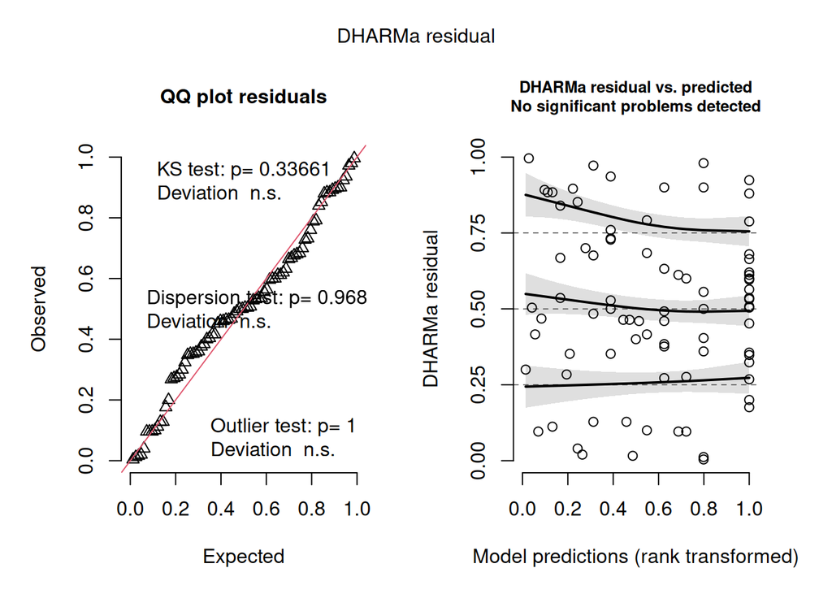

```r
simulationOutput_slope <- simulateResiduals(fittedModel = lmer_slope_3, plot = F)
plot(simulationOutput_slope)
```

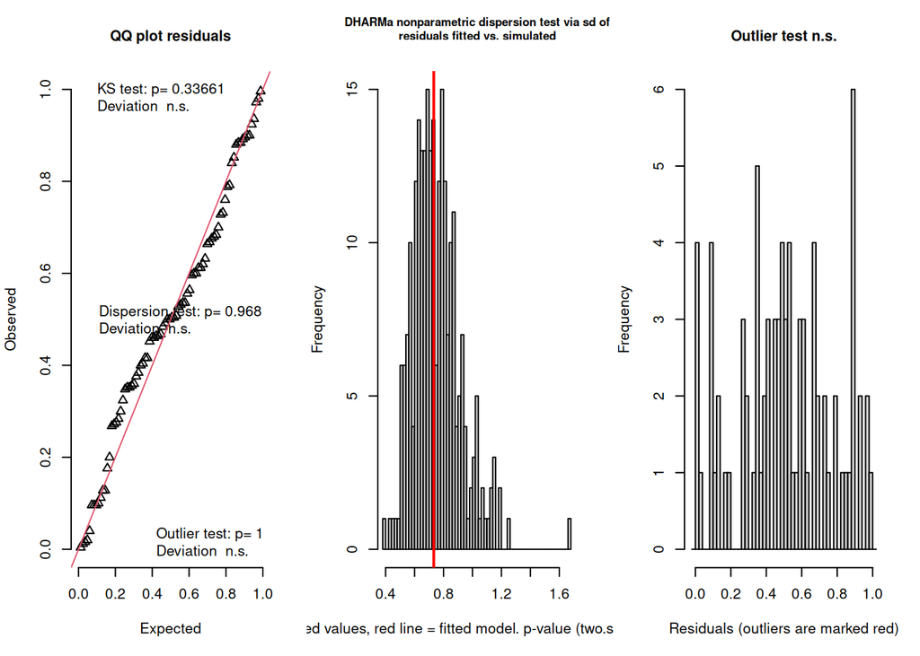

```
## $uniformity
##
##  Asymptotic one-sample Kolmogorov-Smirnov test
##
## data:  simulationOutput$scaledResiduals
## D = 0.1041, p-value = 0.3366
## alternative hypothesis: two-sided
##
##
## $dispersion
##
##  DHARMa nonparametric dispersion test via sd of residuals fitted vs.
##  simulated
##
## data:  simulationOutput
## dispersion = 0.9719, p-value = 0.968
## alternative hypothesis: two.sided
##
##
## $outliers
##
##  DHARMa outlier test based on exact binomial test with approximate
##  expectations
##
## data:  simulationOutput
## outliers at both margin(s) = 0, observations = 82, p-value = 1
## alternative hypothesis: true probability of success is not equal to 0.007968127
## 95 percent confidence interval:
##  0.00000000 0.04398945
## sample estimates:
## frequency of outliers (expected: 0.00796812749003984 )
##                                                      0
```

```r
testResiduals(simulationOutput_slope)
```

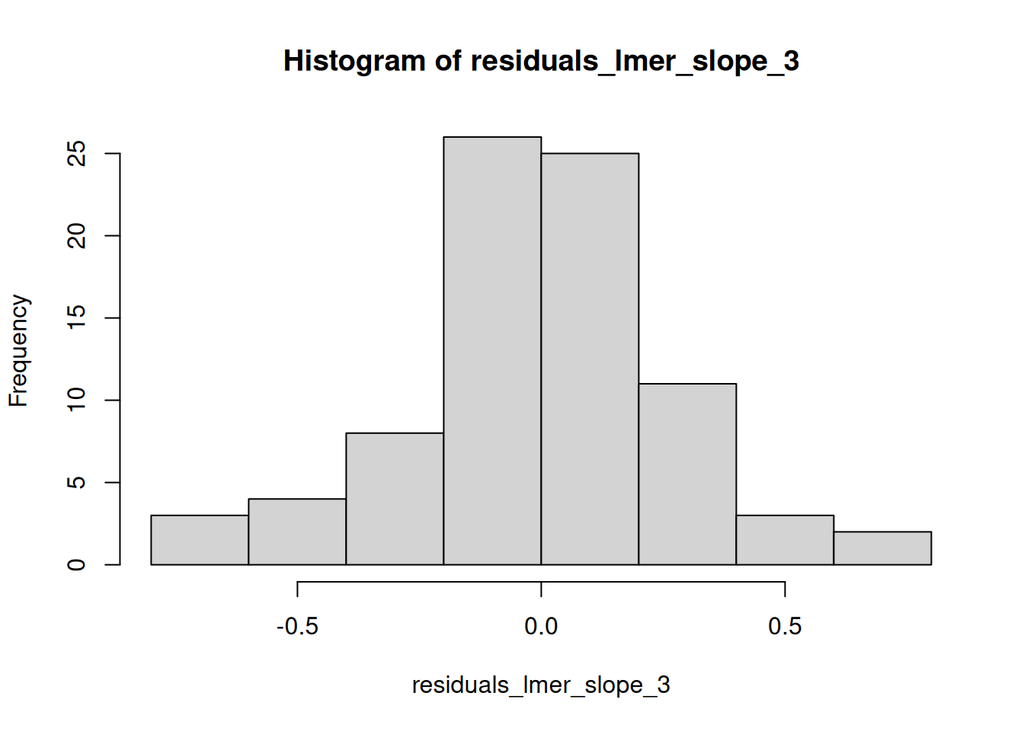

```r
residuals_lmer_slope_3 <- residuals(lmer_slope_3)
hist(residuals_lmer_slope_3)
```

```r
shapiro.test(residuals(lmer_slope_3))
```

```
##
##  Shapiro-Wilk normality test
##
## data:  residuals(lmer_slope_3)
## W = 0.96865, p-value = 0.04218
```

**The infection status and the infestation status of the nest are fixed effects influencing the growth of birds based on calculated slope**

Visualisation:

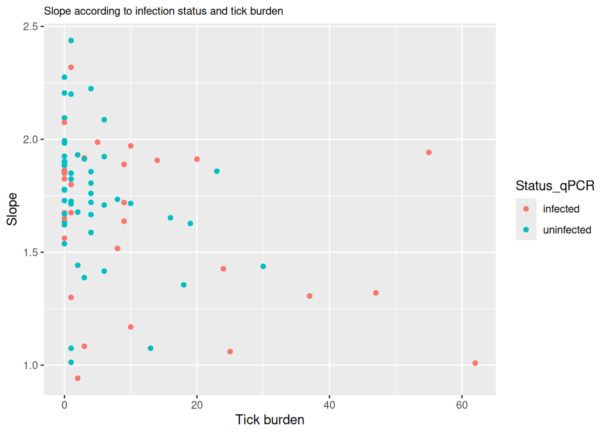

```r
plotC_1 <- ggplot(data_1_slope, aes(x= Ticks_by_nest, y= slope, color=Status_qPCR, fill=Status_qPCR))+
  geom_point() +
labs(x = "Tick burden",
       y = "Slope",
       title = "Slope according to infection status and tick burden")+
  theme(plot.title = element_text(size = 9),
        legend.position = "right")
plotC_1
```

Another visualisation:

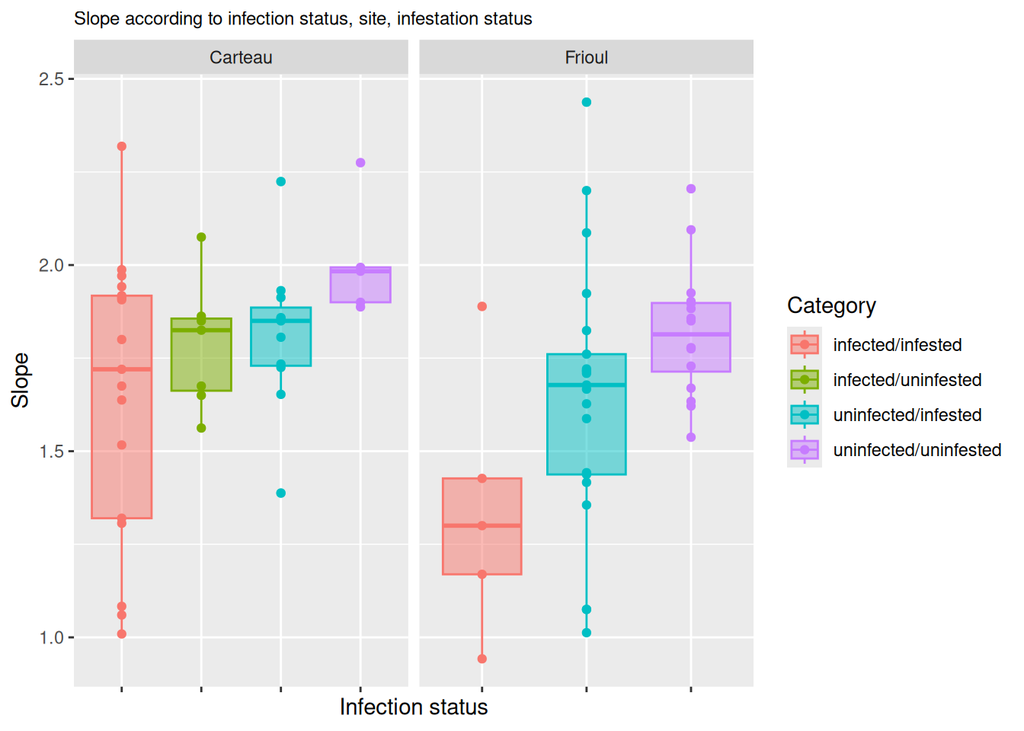

```r
data_1_slope_graph <- unite(data_1_slope, Status_qPCR, Infestation, col = "Category", sep = "/")
plotC_2 <- ggplot(data_1_slope_graph, aes(x= Category, y= slope, color=Category, fill=Category))+
  geom_point(position = position_dodge(width = 0.75)) +
  geom_boxplot(alpha=0.5) +
labs(x = "Infection status",
       y = "Slope",
       title = "Slope according to infection status, site, infestation status")+
  theme(plot.title = element_text(size = 9),
        legend.position = "right",
        axis.text.x = element_blank()) +
  facet_grid(~Site, scales = "free")
plotC_2
```

# 3. Impact of infection on survival

## 3.1. Probability of chicks reaching the final ringing age

```r
data_darvic <- read_excel("Data_Impact of infection on reproductive success_survival_darvic.xlsx")
data_darvic$Site <- as.factor(data_darvic$Site)
data_darvic$Year <- as.factor(data_darvic$Year)
data_darvic$Nest <- as.factor(data_darvic$Nest)
data_darvic$Status_juv <- as.factor(data_darvic$Status_juv)
data_darvic$Status_ad <- as.factor(data_darvic$Status_ad)
data_darvic$Repro_success <- as.numeric(data_darvic$Repro_success)
data_darvic$Bab_ratio_ad <- as.numeric(data_darvic$Bab_ratio_ad)
data_darvic$Sex_ad <- as.factor(data_darvic$Sex_ad)
```

With:  
-Site: sampling colony (Carteau/Frioul)  
-Year: sampling year (2022/2023/2024)  
-Nest: nest of bird  
-Status_juv: infection status based on qPCR technique (uninfected/infected) of the chick  
-Status_ad: infection status based on qPCR technique (uninfected/infected) of the adult  
-Repro_success: reproductive success of the adult determined by the fact that we placed a Darvic ring on the chick (i.e. the chick reached the ringing age) (0: not ringed/1: ringed)  
-Ad_name: ID of adult bird  
-Bab_ratio_ad: quantification of *Babesia* based on qPCR technique (ratio Larus/*Babesia* copies of genes)  
-Sex_ad: sex of the adult bird (F/M)  
-Ticks_by_nest: number of ticks collected in the nest

Individuals for whom the infection status of the adult and number of ticks in the nest have not been determined are removed:

```r
data_darvic_ticks <- data_darvic %>%
  filter(!is.na(Ticks_by_nest))
data_darvic_ticks$Ticks_by_nest <- as.numeric(data_darvic_ticks$Ticks_by_nest)

data_darvic_ticks_ad <- data_darvic_ticks %>%
  filter(!is.na(Status_ad))

data_darvic_ad <- data_darvic %>%
  filter(!is.na(Status_ad))
```

### 3.1.1. Fisher’s test

```r
tabCont_darvic_ad <- table(data_darvic_ticks_ad$Repro_success, data_darvic_ticks_ad$Status_ad)
tabCont_darvic_ad_marg <- addmargins(tabCont_darvic_ad)
print(tabCont_darvic_ad_marg)
```

```
##
##       infected uninfected Sum
##   0          7         27  34
##   1          2         63  65
##   Sum        9         90  99
```

```r
fisher.test(tabCont_darvic_ad)
```

```
##
##  Fisher's Exact Test for Count Data
##
## data:  tabCont_darvic_ad
## p-value = 0.007176
## alternative hypothesis: true odds ratio is not equal to 1
## 95 percent confidence interval:
##   1.399972 83.756712
## sample estimates:
## odds ratio
##   7.978658
```

**p-value = 0.007176**  
We therefore consider that the proportions are significantly different.

### 3.1.2. Model GLMER

We include the variables `Status_ad` and `Ticks_by_nest` as fixed effects and `Site` and `Year` as random effects in our full GLMER model (binomial family):

```r
glmer_full_ad <- glmer(Repro_success ~ Status_ad + Ticks_by_nest + (1|Site) + (1|Year), family=binomial(link = "logit"), data=data_darvic_ticks_ad)
glmer_1_ad <- glmer(Repro_success ~ Status_ad + (1|Site) + (1|Year), family=binomial(link = "logit"), data=data_darvic_ticks_ad)
glmer_2_ad <- glmer(Repro_success ~ Ticks_by_nest + (1|Site) + (1|Year), family=binomial(link = "logit"), data=data_darvic_ticks_ad)
glmer_null_ad <- glmer(Repro_success ~ 1 + (1|Site) + (1|Year), family=binomial(link = "logit"), data=data_darvic_ticks_ad)

anova_darvic_1 <- anova(glmer_full_ad, glmer_1_ad, test="Chisq")
anova_darvic_2 <- anova(glmer_full_ad, glmer_2_ad, test="Chisq")
anova_darvic_3 <- anova(glmer_1_ad, glmer_null_ad, test="Chisq")
anova_darvic_4 <- anova(glmer_2_ad, glmer_null_ad, test="Chisq")

p_value_anova_darvic_1 <- anova_darvic_1$`Pr(>Chisq)`[2]
p_value_anova_darvic_2 <- anova_darvic_2$`Pr(>Chisq)`[2]
p_value_anova_darvic_3 <- anova_darvic_3$`Pr(>Chisq)`[2]
p_value_anova_darvic_4 <- anova_darvic_4$`Pr(>Chisq)`[2]

anova_results_darvic <- data.frame(
  Comparison = c("full vs Status_ad", "full vs Ticks_by_nest", "null vs Status_ad", "null vs Ticks_by_nest"),
  P_value = c(p_value_anova_darvic_1, p_value_anova_darvic_2, p_value_anova_darvic_3, p_value_anova_darvic_4))

anova_results_darvic %>%
  kable(caption = "ANOVA Results between models") %>%
  kable_styling(bootstrap_options = c("striped", "hover", "condensed", "responsive"))
```

ANOVA Results between models

| Comparison | P_value |
| --- | --- |
| full vs Status_ad | 0.7059827 |
| full vs Ticks_by_nest | 0.0068895 |
| null vs Status_ad | 0.0049968 |
| null vs Ticks_by_nest | 0.3956996 |

```r
tab_model(glmer_full_ad, glmer_1_ad, glmer_2_ad, glmer_null_ad, string.est = "IRR", show.aicc = TRUE, digits=2, show.ci = FALSE, show.intercept = FALSE)
```

|  | Repro_success |  | Repro_success |  | Repro_success |  | Repro_success |  |
| --- | --- | --- | --- | --- | --- | --- | --- | --- |
| Predictors | IRR | p | IRR | p | IRR | p | IRR | p |
| Status ad [uninfected] | 7.79 | **0.015** | 8.17 | **0.012** |  |  |  |  |
| Ticks by nest | 0.99 | 0.703 |  |  | 0.99 | 0.393 |  |  |
| Random Effects |  |  |  |  |  |  |  |  |
| σ<sup>2</sup> | 3.29 |  | 3.29 |  | 3.29 |  | 3.29 |  |
| τ<sub>00</sub> | 0.00 <sub>Year</sub> |  | 0.00 <sub>Year</sub> |  | 0.00 <sub>Year</sub> |  | 0.00 <sub>Year</sub> |  |
|  | 0.00 <sub>Site</sub> |  | 0.00 <sub>Site</sub> |  | 0.00 <sub>Site</sub> |  | 0.00 <sub>Site</sub> |  |
| N | 2 <sub>Site</sub> |  | 2 <sub>Site</sub> |  | 2 <sub>Site</sub> |  | 2 <sub>Site</sub> |  |
|  | 3 <sub>Year</sub> |  | 3 <sub>Year</sub> |  | 3 <sub>Year</sub> |  | 3 <sub>Year</sub> |  |
| Observations | 99 |  | 99 |  | 99 |  | 99 |  |
| Marginal R<sup>2</sup> / Conditional R<sup>2</sup> | 0.103 / NA |  | 0.101 / NA |  | 0.009 / NA |  | 0.000 / NA |  |
| AICc | 129.993 |  | 127.916 |  | 135.075 |  | 133.624 |  |

**Based on these results, `Status_ad` is a fixed effect influencing the probability of chicks reaching the final ringing age.**

We examine the best-fitted model:

```r
summary(glmer_1_ad)
```

```
## Generalized linear mixed model fit by maximum likelihood (Laplace
##   Approximation) [glmerMod]
##  Family: binomial  ( logit )
## Formula: Repro_success ~ Status_ad + (1 | Site) + (1 | Year)
##    Data: data_darvic_ticks_ad
##
##       AIC       BIC    logLik -2*log(L)  df.resid
##     127.5     137.9     -59.7     119.5        95
##
## Scaled residuals:
##     Min      1Q  Median      3Q     Max
## -1.5275 -1.5275  0.6546  0.6546  1.8708
##
## Random effects:
##  Groups Name        Variance Std.Dev.
##  Year   (Intercept) 0        0
##  Site   (Intercept) 0        0
## Number of obs: 99, groups:  Year, 3; Site, 2
##
## Fixed effects:
##                     Estimate Std. Error z value Pr(>|z|)
## (Intercept)          -1.2528     0.8018  -1.562   0.1182
## Status_aduninfected   2.1001     0.8341   2.518   0.0118 *
## ---
## Signif. codes:  0 '***' 0.001 '**' 0.01 '*' 0.05 '.' 0.1 ' ' 1
##
## Correlation of Fixed Effects:
##             (Intr)
## Stts_dnnfct -0.961
## optimizer (Nelder_Mead) convergence code: 0 (OK)
## boundary (singular) fit: see help('isSingular')
```

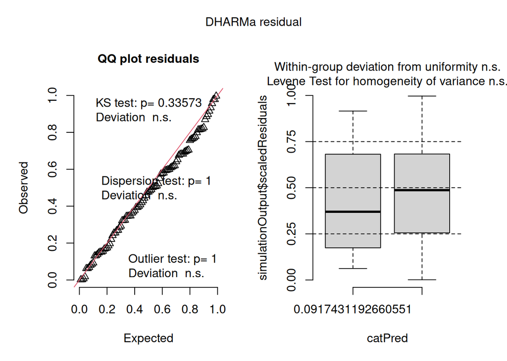

```r
simulationOutput_ad <- simulateResiduals(fittedModel = glmer_1_ad, plot = F)
plot(simulationOutput_ad)
```

Some key results from our model:  
The odds of the reproductive success assessed by the probability of chicks reaching the final ringing age are 8.17 (IRR) times significantly (p = 0.012) higher in uninfected adults compared to the infected ones.

Visualisation:

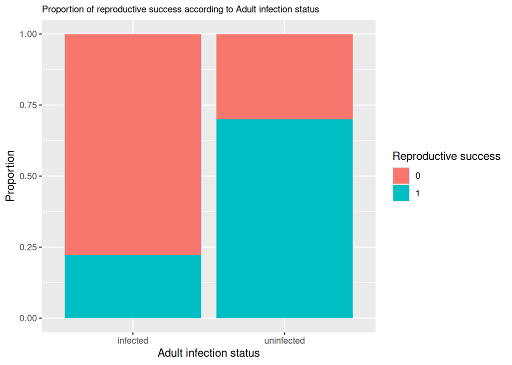

```r
plotD <- ggplot(data_darvic_ticks_ad, aes(x = Status_ad, fill = factor(Repro_success))) +
  geom_bar(position = "fill") +
  labs(y = "Proportion",
       x = "Adult infection status",
       fill = "Reproductive success",
       title = "Proportion of reproductive success according to Adult infection status") +
  theme(plot.title = element_text(size = 9))
plotD
```

### 3.1.3. Comparison of parasitemia between adults with ou without reproductive success

Do infected adults with `Repro_success = 1` have a lower parasitemia than infected adults with `Repro_success = 0`?

Uninfected adults were removed:

```r
data_darvic_ad_inf <- data_darvic_ad[which(data_darvic_ad$Status_ad == "infected"),]
```

```r
shapiro.test(data_darvic_ad_inf$Bab_ratio_ad)
```

```
##
##  Shapiro-Wilk normality test
##
## data:  data_darvic_ad_inf$Bab_ratio_ad
## W = 0.59896, p-value = 9.302e-05
```

**p-value = 9.302e-05**  
We will use a non-parametric test.

```r
wilcox.test(Bab_ratio_ad ~ Repro_success, data = data_darvic_ad_inf)
```

```
##
##  Wilcoxon rank sum exact test
##
## data:  Bab_ratio_ad by Repro_success
## W = 14, p-value = 0.05556
## alternative hypothesis: true location shift is not equal to 0
```

```r
wilcox_effsize(data_darvic_ad_inf, Bab_ratio_ad ~ Repro_success)
```

```
## # A tibble: 1 × 7
##   .y.          group1 group2 effsize    n1    n2 magnitude
## * <chr>        <chr>  <chr>    <dbl> <int> <int> <ord>
## 1 Bab_ratio_ad 0      1        0.683     7     2 large
```

Wilcoxon Rank-Sum Test:  
**p-value = 0.05556**  
This p-value is just above the typical significance threshold of 0.05, meaning the result is not statistically significant at the 5% level. You do not have strong evidence to reject the null hypothesis, so you cannot confidently say there is a difference in `Bab_ratio_ad` between `Repro_success = 0` and `Repro_success = 1`. However, the p-value is close to significance, suggesting that a trend might exist, which could be worth exploring with more data.

Effect Size:  
**Effsize = 0.683**  
An effect size of 0.683 is considered large, meaning there is a substantial difference in `Bab_ratio_ad` between the groups, even if it was not statistically significant.

**Although the p-value suggests the difference is not statistically significant, the large effect size indicates that the difference in `Bab_ratio_ad` between adults with `Repro_success = 0` and `Repro_success = 1` is likely meaningful in practice. The small sample size (especially for `Repro_success = 1`) reduces the power of the test, meaning that you might not have enough data to detect a statistically significant difference.**

We calculate some metrics about `Bab_ratio_qPCR` in both groups:

```r
summary_table <- data_darvic_ad_inf %>%
  group_by(Repro_success) %>%
  summarise(
    Mean = mean(Bab_ratio_ad),
    SD = sd(Bab_ratio_ad),
    SE = sd(Bab_ratio_ad, na.rm = TRUE) / sqrt(length(Bab_ratio_ad)),
    N = n())

summary_table %>%
  kable(caption = "Metrics about Bab_ratio_ad based on Repro_success") %>%
  kable_styling(bootstrap_options = c("striped", "hover", "condensed", "responsive"))
```

Metrics about Bab_ratio_ad based on Repro_success

| Repro_success | Mean | SD | SE | N |
| --- | --- | --- | --- | --- |
| 0 | 0.0001098 | 0.0001812 | 6.85e-05 | 7 |
| 1 | 0.0000001 | 0.0000000 | 0.00e+00 | 2 |

## 3.2. Juvenile survival probability for one month post-fledging

```r
data_fledging <- read_excel("Data_Impact of infection on reproductive success_survival_fledging.xlsx")
data_fledging$Sample <- as.factor(data_fledging$Sample)
data_fledging$Site <- as.factor(data_fledging$Site)
data_fledging$Year <- as.factor(data_fledging$Year)
data_fledging$Sex <- as.factor(data_fledging$Sex)
data_fledging$Status_qPCR <- as.factor(data_fledging$Status_qPCR)
data_fledging$Survival <- as.numeric(data_fledging$Survival)

data_fledging_ticks <- data_fledging %>%
  filter(Ticks_by_nest != "tagged")
data_fledging_ticks$Ticks_by_nest <- as.numeric(data_fledging_ticks$Ticks_by_nest)
```

With:  
-Sample: ID of individual bird  
-Site: sampling colony (Carteau/Frioul)  
-Year: sampling year (2022/2023/2024)  
-Sex: sex of the bird (F/M)  
-Status_qPCR: infection status based on qPCR technique (uninfected/infected)  
-Survival: survival of the chick one month post-fledging (0: death/1: alive)  
-Ticks_by_nest: number of ticks collected in the nest

Individuals with undetermined survival were removed:

```r
data_fledging <- data_fledging %>%
  filter(!is.na(Survival))
```

### 3.2.1. Fisher’s test

```r
tabCont_survival <- table(data_fledging$Survival, data_fledging$Status_qPCR)
tabCont_survival_marg <- addmargins(tabCont_survival)
print(tabCont_survival_marg)
```

```
##
##       infected uninfected Sum
##   0          3          5   8
##   1         12         21  33
##   Sum       15         26  41
```

```r
fisher.test(tabCont_survival)
```

```
##
##  Fisher's Exact Test for Count Data
##
## data:  tabCont_survival
## p-value = 1
## alternative hypothesis: true odds ratio is not equal to 1
## 95 percent confidence interval:
##  0.1381993 6.5650709
## sample estimates:
## odds ratio
##   1.048731
```

**p-value = 1**  
We therefore do not consider that the proportions are significantly different.

### 3.2.2. Model GLMER with data_fledging, without testing the effect of `Ticks_by_nest`

We include the variables `Status_qPCR` as a fixed effect and `Site`, `Sex`, and `Year` as random effects in our full GLMER model (binomial family):

```r
glmer_full_fledging <- glmer(Survival ~ Status_qPCR + (1|Site) + (1|Year) + (1|Sex), family=binomial(link = "logit"), data=data_fledging)
glmer_null_fledging <- glmer(Survival ~ 1 + (1|Site) + (1|Year) + (1|Sex), family=binomial(link = "logit"), data=data_fledging)
AICc(glmer_full_fledging)
```

```
## [1] 48.38487
```

```r
AICc(glmer_null_fledging)
```

```
## [1] 45.84026
```

```r
anova(glmer_full_fledging, glmer_null_fledging, test="Chisq")
```

```
## Data: data_fledging
## Models:
## glmer_null_fledging: Survival ~ 1 + (1 | Site) + (1 | Year) + (1 | Sex)
## glmer_full_fledging: Survival ~ Status_qPCR + (1 | Site) + (1 | Year) + (1 | Sex)
##                     npar    AIC    BIC  logLik -2*log(L)  Chisq Df Pr(>Chisq)
## glmer_null_fledging    4 44.664 51.318 -18.332    36.664
## glmer_full_fledging    5 46.567 54.884 -18.283    36.567 0.0971  1     0.7553
```

```r
tab_model(glmer_full_fledging, glmer_null_fledging, string.est = "IRR", show.aicc = TRUE, digits=2, show.ci = FALSE, show.intercept = FALSE)
```

|  | Survival |  | Survival |  |
| --- | --- | --- | --- | --- |
| Predictors | IRR | p | IRR | p |
| Status qPCR [uninfected] | 1.32 | 0.755 |  |  |
| Random Effects |  |  |  |  |
| σ<sup>2</sup> | 3.29 |  | 3.29 |  |
| τ<sub>00</sub> | 0.13 <sub>Year</sub> |  | 0.09 <sub>Year</sub> |  |
|  | 0.00 <sub>Sex</sub> |  | 0.00 <sub>Sex</sub> |  |
|  | 0.00 <sub>Site</sub> |  | 0.00 <sub>Site</sub> |  |
| N | 2 <sub>Site</sub> |  | 2 <sub>Site</sub> |  |
|  | 3 <sub>Year</sub> |  | 3 <sub>Year</sub> |  |
|  | 2 <sub>Sex</sub> |  | 2 <sub>Sex</sub> |  |
| Observations | 39 |  | 39 |  |
| Marginal R<sup>2</sup> / Conditional R<sup>2</sup> | 0.006 / NA |  | 0.000 / NA |  |
| AICc | 48.385 |  | 45.840 |  |

**Based on these results, `Status_qPCR` is not a fixed effect influencing the probability of survival one month post-fledging.**

```r
summary(glmer_null_fledging)
```

```
## Generalized linear mixed model fit by maximum likelihood (Laplace
##   Approximation) [glmerMod]
##  Family: binomial  ( logit )
## Formula: Survival ~ 1 + (1 | Site) + (1 | Year) + (1 | Sex)
##    Data: data_fledging
##
##       AIC       BIC    logLik -2*log(L)  df.resid
##      44.7      51.3     -18.3      36.7        35
##
## Scaled residuals:
##     Min      1Q  Median      3Q     Max
## -2.2889  0.4369  0.4398  0.4973  0.4973
##
## Random effects:
##  Groups Name        Variance  Std.Dev.
##  Year   (Intercept) 9.409e-02 3.067e-01
##  Sex    (Intercept) 4.713e-09 6.865e-05
##  Site   (Intercept) 4.890e-09 6.993e-05
## Number of obs: 39, groups:  Year, 3; Sex, 2; Site, 2
##
## Fixed effects:
##             Estimate Std. Error z value Pr(>|z|)
## (Intercept)   1.5693     0.5196    3.02  0.00252 **
## ---
## Signif. codes:  0 '***' 0.001 '**' 0.01 '*' 0.05 '.' 0.1 ' ' 1
## optimizer (Nelder_Mead) convergence code: 0 (OK)
## boundary (singular) fit: see help('isSingular')
```

Visualisation:

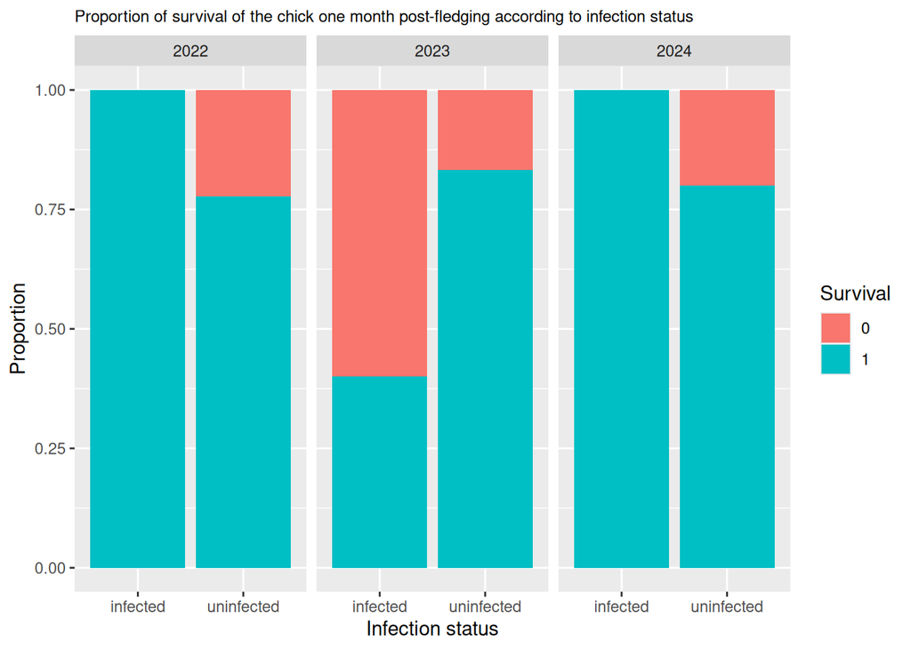

```r
plotE <- ggplot(data_fledging, aes(x = Status_qPCR, fill = factor(Survival))) +
  geom_bar(position = "fill") +
  labs(y = "Proportion",
       x = "Infection status",
       fill = "Survival",
       title = "Proportion of survival of the chick one month post-fledging according to infection status") +
  theme(plot.title = element_text(size = 9)) +
  facet_grid(~Year)
plotE
```

### 3.2.3. Model GLMER with data_fledging_ticks, testing the effect of `Ticks_by_nest`

Individuals with undetermined survival were removed:

```r
data_fledging_ticks <- data_fledging_ticks %>%
  filter(!is.na(Survival))
```

n = 29 (against n = 41 if not testing `Ticks_by_nest`)

We include the variables `Status_qPCR` and `Ticks_by_nest` as fixed effects and `Site`, `Sex`, and `Year` as random effects in our full GLMER model (binomial family):

```r
glmer_full_fledging <- glmer(Survival ~ Status_qPCR + Ticks_by_nest + (1|Site) + (1|Year) + (1|Sex), family=binomial(link = "logit"), data=data_fledging_ticks)
glmer_1_fledging <- glmer(Survival ~ Status_qPCR + (1|Site) + (1|Year) + (1|Sex), family=binomial(link = "logit"), data=data_fledging_ticks)
glmer_2_fledging <- glmer(Survival ~ Ticks_by_nest + (1|Site) + (1|Year) + (1|Sex), family=binomial(link = "logit"), data=data_fledging_ticks)
glmer_null_fledging <- glmer(Survival ~ 1 + (1|Site) + (1|Year) + (1|Sex), family=binomial(link = "logit"), data=data_fledging_ticks)

anova_fledging_1 <- anova(glmer_full_fledging, glmer_1_fledging, test="Chisq")
anova_fledging_2 <- anova(glmer_full_fledging, glmer_2_fledging, test="Chisq")
anova_fledging_3 <- anova(glmer_1_fledging, glmer_null_fledging, test="Chisq")
anova_fledging_4 <- anova(glmer_2_fledging, glmer_null_fledging, test="Chisq")

p_value_anova_fledging_1 <- anova_fledging_1$`Pr(>Chisq)`[2]
p_value_anova_fledging_2 <- anova_fledging_2$`Pr(>Chisq)`[2]
p_value_anova_fledging_3 <- anova_fledging_3$`Pr(>Chisq)`[2]
p_value_anova_fledging_4 <- anova_fledging_4$`Pr(>Chisq)`[2]

anova_results_fledging <- data.frame(
  Comparison = c("full vs Status_qPCR", "full vs Ticks_by_nest", "null vs Status_qPCR", "null vs Ticks_by_nest"),
  P_value = c(p_value_anova_fledging_1, p_value_anova_fledging_2, p_value_anova_fledging_3, p_value_anova_fledging_4))

anova_results_fledging %>%
  kable(caption = "ANOVA Results between models") %>%
  kable_styling(bootstrap_options = c("striped", "hover", "condensed", "responsive"))
```

ANOVA Results between models

| Comparison | P_value |
| --- | --- |
| full vs Status_qPCR | 0.0436094 |
| full vs Ticks_by_nest | 0.3333909 |
| null vs Status_qPCR | 0.8872170 |
| null vs Ticks_by_nest | 0.0756458 |

```r
tab_model(glmer_full_fledging, glmer_1_fledging, glmer_2_fledging, glmer_null_fledging, string.est = "IRR", show.aicc = TRUE, digits=2, show.ci = FALSE, show.intercept = FALSE)
```

|  | Survival |  | Survival |  | Survival |  | Survival |  |
| --- | --- | --- | --- | --- | --- | --- | --- | --- |
| Predictors | IRR | p | IRR | p | IRR | p | IRR | p |
| Status qPCR [uninfected] | 5.27 | 0.333 | 0.83 | 0.888 |  |  |  |  |
| Ticks by nest | 3.27 | 0.263 |  |  | 2.17 | 0.393 |  |  |
| Random Effects |  |  |  |  |  |  |  |  |
| σ<sup>2</sup> | 3.29 |  | 3.29 |  | 3.29 |  | 3.29 |  |
| τ<sub>00</sub> | 0.00 <sub>Year</sub> |  | 0.00 <sub>Year</sub> |  | 0.00 <sub>Year</sub> |  | 0.00 <sub>Year</sub> |  |
|  | 0.00 <sub>Sex</sub> |  | 0.00 <sub>Sex</sub> |  | 0.00 <sub>Sex</sub> |  | 0.00 <sub>Sex</sub> |  |
|  | 0.00 <sub>Site</sub> |  | 0.00 <sub>Site</sub> |  | 0.00 <sub>Site</sub> |  | 0.00 <sub>Site</sub> |  |
| N | 2 <sub>Site</sub> |  | 2 <sub>Site</sub> |  | 2 <sub>Site</sub> |  | 2 <sub>Site</sub> |  |
|  | 3 <sub>Year</sub> |  | 3 <sub>Year</sub> |  | 3 <sub>Year</sub> |  | 3 <sub>Year</sub> |  |
|  | 2 <sub>Sex</sub> |  | 2 <sub>Sex</sub> |  | 2 <sub>Sex</sub> |  | 2 <sub>Sex</sub> |  |
| Observations | 27 |  | 27 |  | 27 |  | 27 |  |
| Marginal R<sup>2</sup> / Conditional R<sup>2</sup> | 0.983 / NA |  | 0.002 / NA |  | 0.963 / NA |  | 0.000 / NA |  |
| AICc | 30.945 |  | 31.674 |  | 28.538 |  | 28.655 |  |

**Based on these results, `Status_qPCR` is not a fixed effect influencing the probability of survival one month post-fledging.**

```r
summary(glmer_1_fledging)
```

```
## Generalized linear mixed model fit by maximum likelihood (Laplace
##   Approximation) [glmerMod]
##  Family: binomial  ( logit )
## Formula: Survival ~ Status_qPCR + (1 | Site) + (1 | Year) + (1 | Sex)
##    Data: data_fledging_ticks
##
##       AIC       BIC    logLik -2*log(L)  df.resid
##      28.8      35.3      -9.4      18.8        22
##
## Scaled residuals:
##     Min      1Q  Median      3Q     Max
## -3.0000  0.3333  0.3651  0.3651  0.3651
##
## Random effects:
##  Groups Name        Variance  Std.Dev.
##  Year   (Intercept) 1.155e-16 1.074e-08
##  Sex    (Intercept) 8.828e-18 2.971e-09
##  Site   (Intercept) 0.000e+00 0.000e+00
## Number of obs: 27, groups:  Year, 3; Sex, 2; Site, 2
##
## Fixed effects:
##                       Estimate Std. Error z value Pr(>|z|)
## (Intercept)             2.1972     1.0541   2.084   0.0371 *
## Status_qPCRuninfected  -0.1823     1.2953  -0.141   0.8881
## ---
## Signif. codes:  0 '***' 0.001 '**' 0.01 '*' 0.05 '.' 0.1 ' ' 1
##
## Correlation of Fixed Effects:
##             (Intr)
## Stts_qPCRnn -0.814
## optimizer (Nelder_Mead) convergence code: 0 (OK)
## boundary (singular) fit: see help('isSingular')
```

Visualisation:

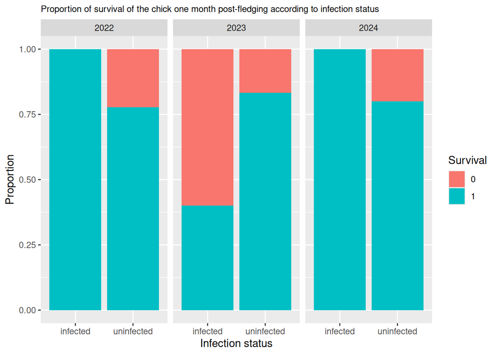

```r
plotE <- ggplot(data_fledging, aes(x = Status_qPCR, fill = factor(Survival))) +
  geom_bar(position = "fill") +
  labs(y = "Proportion",
       x = "Infection status",
       fill = "Survival",
       title = "Proportion of survival of the chick one month post-fledging according to infection status") +
  theme(plot.title = element_text(size = 9)) +
  facet_grid(~Year)
plotE
```

# 4. Summary

**The growth of birds, either represented by calculated residuals or slope, is influenced by the infection status**.  
**According to residuals**, our best-fitted model highlights that growth is a factor that is difficult to explain using a single variable - the combination of predictors (`Status_qPCR`, `Sex`, `Ticks_by_nest`, and Status_qPCR/Sex interaction) plus the random effects structure yields the most parsimonious fit to your data. So, the infection status appears to influence slightly the growth of birds based on calculated residuals.  
With this model, males exhibit higher residuals than females (LMER, IRR = 5.43, p = 0.331) and uninfected individuals have (LMER, IRR = 4.53, p = 0.423) higher residuals than infected ones. In addition, tick burden shows a significant negative impact on growth (IRR = -0.34, p = 0.036).

**According to slope**, uninfected individuals have significantly higher slope than infected ones (IRR = 0.17, p = 0.035), even considering negative ticks’ impact (IRR = -0.01, p = 0.008) (LMER, AICc = 57.29).

While looking at the impact of *Babesia* parasitemia, tests suggest that it plays a role to the variances of residuals at time t (LMER, p-value ANOVA vs null = 0.004, AICc = 145.14 vs 149.25, IRR = -1.21, p = 0.003). **There is a negative correlation between the residuals at time t and the parasitemia**.

Looking at the impact of infection status on survival, **it influences the probability of chicks reaching the final ringing age depending on the status of adults (Fisher’s test, p-value = 0.007176; GLMER, p-value ANOVA vs null = 0.005, AICc = 127.92 vs 133.62, IRR = 8.17, p = 0.012)**, meaning that the probability of reaching the final ringing age of chicks from uninfected adults are 8.17 times higher compared to the infected ones.  
However, the infection status doesn’t influence the probability of survival one month post-fledging (Fisher’s test, p-value = 1; GLMER, p-value ANOVA vs null = 0.7553, AICc = 48.38 vs 45.84, p = 0.755). **This conclusion doesn’t change while testing tick burden impact.**